# Eren Destan - Personal Challange

[figure not shown]

# 1- Introduction 🗿

### Project Overview and Purpose

This notebook forms a part of the "Personal Challenge" project, which aims to develop a predictive model for cryptocurrency trading. `Basically, the purpose of this project is to develop a predictive model using various technical indicators and machine learning techniques to analyze bitcoin market data. By evaluating the relationship between market indicators and historical price data, the project aims to provide actionable insights into potential price movements and trading opportunities`, assisting traders and investors in making informed decisions in the highly dynamic and volatile cryptocurrency market.

The focus is on assisting small to mid-sized traders in making informed decisions by analyzing historical Bitcoin data from 2015 to 2024. These traders often lack access to sophisticated tools that larger institutions possess, making it challenging to navigate the volatile cryptocurrency market effectively.

### Disclaimer

It's important to note that this predictive model is intended as a supplementary tool to help in analysis and trading decisions. **It is not designed to serve as a standalone decision maker. Market conditions can be unpredictable and may not always align with historical patterns. As such, traders should use this tool in combination with their judgment and consider other market factors.**

### Summary of Domain Understanding

#### Decentralized Market

The cryptocurrency market operates in a decentralized manner, meaning there is no central authority or governing body controlling it. Transactions are recorded on a distributed ledger called the blockchain, which ensures transparency and security. This decentralization contrasts with traditional financial markets, where a central authority oversees transactions.

#### Market Participants

Participants in the cryptocurrency market include:

- **Individual Traders**: Buy and sell cryptocurrencies for profit.
- **Investors**: Hold cryptocurrencies for long-term gains.
- **Institutional Investors**: Large entities that invest substantial amounts in cryptocurrencies.
- **Cryptocurrency Exchanges**: Platforms that facilitate the buying and selling of cryptocurrencies.
- **Miners**: Validate transactions and add them to the blockchain in exchange for new bitcoins.
- **Developers**: Contribute to the development and improvement of blockchain technology.

#### Factors Influencing Prices

Prices in the cryptocurrency market are influenced by a variety of factors:

- **Supply and Demand**: Fundamental economic principles where the price increases when demand exceeds supply and decreases when supply exceeds demand.
- **Market Sentiment**: The overall attitude of traders and investors towards a particular cryptocurrency, which can be influenced by news, events, and social media.
- **Regulatory Environment**: Government regulations and legal rulings can impact market sentiment and influence prices, adding an element of uncertainty and volatility.
- **Technological Developments**: Innovations and advancements in blockchain technology, such as protocol upgrades or new features, can affect prices positively by increasing confidence in a cryptocurrency's future utility and adoption.
- **Market Manipulation**: Due to the relatively small size and lack of regulation, the cryptocurrency market is susceptible to manipulation activities like pump and dump schemes, spoofing, and wash trading, which can artificially inflate or deflate prices. However, Bitcoin, due to its larger market capitalization, broader adoption, and extensive network effects, is generally less affected by market manipulation compared to other smaller cryptocurrencies.

#### Market Volatility

The cryptocurrency market is known for its high volatility, with prices often experiencing significant fluctuations over short periods. Factors contributing to this volatility include:

- **News Events**: Positive or negative news can cause rapid price changes.
- **Market Sentiment Shifts**: Changes in trader and investor attitudes can lead to sudden price movements.
- **Large Buy or Sell Orders**: Significant transactions by large holders (whales) can cause substantial price swings.

While volatility presents opportunities for traders to profit from price movements, it also poses risks, particularly for inexperienced or leveraged traders who may incur substantial losses during periods of extreme volatility.

#### Bitcoin's Unique Characteristics

Bitcoin, the first cryptocurrency, has several unique features that differentiate it from other cryptocurrencies:

- **First Cryptocurrency**: Introduced in 2008 by an anonymous person or group known as Satoshi Nakamoto, Bitcoin remains the largest and most widely recognized cryptocurrency by market capitalization.
- **Capped Supply**: Bitcoin has a capped supply of 21 million coins, which contributes to its scarcity and has led to comparisons with gold as a store of value. This limited supply is designed to control inflation and increase value over time.
- **Mining Process**: Bitcoins are produced through a process called mining. Miners use powerful computers to solve complex mathematical problems that validate transactions on the Bitcoin network. Successful miners are rewarded with newly created bitcoins, which incentivizes the maintenance and security of the network.
- **Halving Events**: Approximately every four years, the reward for mining new blocks is halved in an event known as the "halving." This periodic reduction in the rate of supply growth is designed to decrease the issuance of new bitcoins gradually, increasing scarcity and potentially influencing prices upwards.

Understanding these aspects is crucial for developing effective predictive models and trading strategies.

In this notebook, you will find the following sections in order:

1. **Data Collection and Loading**: Detailed information on the data sources used for the project, including the historical Bitcoin data and technical indicators.
2. **Exploratory Data Analysis (EDA)**: An examination of the price and indicators with statistical and visualization techniques to uncover patterns, correlations, and insights that inform the feature selection process. *All graphs related to indicators will include historical examples to make them understandable for readers with no prior knowledge, providing context and clarity.*
3. **Feature Selection and Engineering**: A description of the methods used to identify and create the most relevant features for the predictive model.
4. **Model Development**: An overview of the machine learning techniques and algorithms used to build the predictive model.
5. **Performance Evaluation**: An assessment of the predictive model's effectiveness using various performance metrics such as precision, recall, F1-score, and cumulative returns.
6. **Developing a Trading Strategy**: The creation of a trading strategy based on the chosen indicators. This section explains the logic and rules behind the strategy, detailing how the selected indicators are used to make trading decisions.
7. **Backtesting/Simulation with Historic Data**: The simulation of the developed trading strategy using historical data. This section includes backtesting to evaluate the strategy's potential profitability and risk, providing insights into how the strategy, assisted by the model's price change predictions, would perform in real-world trading scenarios.

### Objectives

The main objectives of this notebook are to:

1. **Explore and Analyze Bitcoin Data:** Understand the underlying patterns and trends in the historical data.
2. **Feature Engineering:** Identify and select key features that could predict future price movements.
3. **Model Development:** Construct and train a machine learning model using the selected features.
4. **Model Evaluation and Validation:** Assess the model's performance using precision, recall, and F1-score, and validate it through backtesting.
5. **Insights and Recommendations:** Provide actionable insights based on the model's predictions and suggest potential trading strategies.

# 2- Data Collection/Loading 📦

### Data Sourcing

- The dataset was sourced from Kaggle, specifically from the dataset titled "Bitcoin Price Trends with Indicators (8 years)" which can be found [here](https://www.kaggle.com/datasets/aspillai/bitcoin-price-trends-with-indicators-8-years/data). This dataset provides comprehensive historical data on Bitcoin prices along with various technical indicators over the past eight years.
- The dataset is provided under the *CC0: Public Domain license*, `which means it is freely available for public use with no copyright restrictions`. This license allows for the data to be used, modified, and distributed without any limitations, ensuring compliance and flexibility for this project.
- It is important to note that the publisher did not specify the exact sources from which the data was scraped. However, `this does not impact the reliability or utility of the dataset because Bitcoin price data and technical indicators are universal and consistent across different platforms and exchanges`. Therefore, regardless of the specific source, the dataset accurately reflects Bitcoin's market activity and the relevant indicators.
- **The key attributes of this dataset include**:
  - **Bitcoin Price Data**: Daily open, high, low, close, and volume data for Bitcoin.
  - **Technical Indicators**: Various indicators such as Relative Strength Index (RSI), Commodity Channel Index (CCI), Simple Moving Average (SMA), Exponential Moving Average (EMA), Moving Average Convergence Divergence (MACD), Bollinger Bands, True Range, and Average True Range (ATR).

### Data Requirements

- The features currently available in the dataset can be used to create a predictive model for forecasting potential price movements and identifying trading opportunities in the cryptocurrency market. These features include both price-related data and technical indicators, which are essential for building a robust and accurate predictive model.
- What could be added:
  - Although additional indicators could be added to potentially enhance the model, the current dataset includes some of the most popular and widely used indicators for cryptocurrency analysis. These indicators cover essential aspects like price, volatility, and momentum, making the dataset comprehensive and well-suited for providing valuable insights and predictive capabilities. So, I decided that what I have on that dataset is already more than enough.

#### Data Dictionary

| Data Element | Category | Data Type | Range | Description |
| --- | --- | --- | --- | --- |
| date | Date | Date | N/A | The date of the data entry. |
| open | Price | Float | 0 to 60,000+ | The opening price of Bitcoin on the given date. |
| high | Price | Float | 0 to 60,000+ | The highest price of Bitcoin on the given date. |
| low | Price | Float | 0 to 60,000+ | The lowest price of Bitcoin on the given date. |
| close | Price | Float | 0 to 60,000+ | The closing price of Bitcoin on the given date. |
| volume | Volume | Float | 0 to billions | The total volume of Bitcoin traded on the given date. |
| rsi_7 | Momentum | Float | 0 to 100 | The 7-day Relative Strength Index. |
| rsi_14 | Momentum | Float | 0 to 100 | The 14-day Relative Strength Index. |
| cci_7 | Momentum | Float | -200 to 200+ | The 7-day Commodity Channel Index. |
| cci_14 | Momentum | Float | -200 to 200+ | The 14-day Commodity Channel Index. |
| sma_50 | Trend | Float | 0 to 60,000+ | The 50-day Simple Moving Average. |
| ema_50 | Trend | Float | 0 to 60,000+ | The 50-day Exponential Moving Average. |
| sma_100 | Trend | Float | 0 to 60,000+ | The 100-day Simple Moving Average. |
| ema_100 | Trend | Float | 0 to 60,000+ | The 100-day Exponential Moving Average. |
| macd | Momentum | Float | -5000 to 5000+ | The Moving Average Convergence Divergence. |
| bollinger | Volatility | Float | 0 to 60,000+ | Bollinger Bands (Upper and Lower bands). |
| TrueRange | Volatility | Float | 0 to 60,000+ | The True Range. |
| atr_7 | Volatility | Float | 0 to 60,000+ | The 7-day Average True Range. |
| atr_14 | Volatility | Float | 0 to 60,000+ | The 14-day Average True Range. |
| next_day_close | Price | Float | 0 to 60,000+ | The closing price of Bitcoin on the next day (target variable). |

### 2.1 - Loading the Dataset and Importing the Libraries

```python
import pandas as pd
import numpy as np
import matplotlib.pyplot as plt
import seaborn as sns
from scipy import stats
import plotly.express as px
import plotly.graph_objects as go
from plotly.offline import init_notebook_mode
init_notebook_mode(connected=True)
import plotly.express as px
import plotly.graph_objects as go
from plotly.subplots import make_subplots
from plotly.offline import init_notebook_mode
import seaborn as sns
import matplotlib.dates as mdates


df_bitcoin_2015_2024 = pd.read_csv("../Personal Challange Research etc/Datasets/btc_2015_2024with_indicators.csv")

df_bitcoin_2015_2024.head(5)
```

|  | date | open | high | low | close | volume | rsi_7 | rsi_14 | cci_7 | cci_14 | sma_50 | ema_50 | sma_100 | ema_100 | macd | bollinger | TrueRange | atr_7 | atr_14 | next_day_close |
| --- | --- | --- | --- | --- | --- | --- | --- | --- | --- | --- | --- | --- | --- | --- | --- | --- | --- | --- | --- | --- |
| 0 | 2015-01-02 | 314.079010 | 315.838989 | 313.565002 | 315.032013 | 7860650.0 | 100.000000 | 100.000000 | -66.666667 | -66.666667 | 314.640503 | 314.648333 | 314.640503 | 314.644418 | 0.017568 | 314.640503 | 2.273987 | 4.193073 | 4.275997 | 281.082001 |
| 1 | 2015-01-03 | 314.846008 | 315.149994 | 281.082001 | 281.082001 | 33054400.0 | 1.938583 | 2.096744 | -100.000000 | -100.000000 | 303.454336 | 303.009081 | 303.454336 | 303.232458 | -1.030403 | 303.454336 | 34.067993 | 15.719617 | 14.951008 | 264.195007 |
| 2 | 2015-01-04 | 281.145996 | 287.230011 | 257.612000 | 264.195007 | 55629100.0 | 1.235506 | 1.375421 | -110.693896 | -110.693896 | 293.639503 | 292.715747 | 293.639503 | 293.178382 | -2.091487 | 293.639503 | 29.618011 | 20.033779 | 19.034849 | 274.473999 |
| 3 | 2015-01-05 | 265.084015 | 278.341003 | 265.084015 | 274.473999 | 43962800.0 | 21.462825 | 19.523695 | -76.487357 | -76.487357 | 289.806403 | 288.769813 | 289.806403 | 289.286389 | -2.215008 | 289.806403 | 14.145996 | 18.468441 | 17.907070 | 286.188995 |
| 4 | 2015-01-06 | 274.610992 | 287.553009 | 272.696014 | 286.188995 | 23245700.0 | 38.272356 | 34.350787 | -37.070244 | -37.070244 | 289.203501 | 288.295540 | 289.203501 | 288.744005 | -1.746686 | 289.203501 | 14.856995 | 17.613461 | 17.300126 | 294.337006 |

# 2.1- Data Understanding/Data Inspection 👁️🍄🔮🎪🎭🛤️🕯️

```python
df_bitcoin_2015_2024.sample(10)
```

|  | date | open | high | low | close | volume | rsi_7 | rsi_14 | cci_7 | cci_14 | sma_50 | ema_50 | sma_100 | ema_100 | macd | bollinger | TrueRange | atr_7 | atr_14 | next_day_close |
| --- | --- | --- | --- | --- | --- | --- | --- | --- | --- | --- | --- | --- | --- | --- | --- | --- | --- | --- | --- | --- |
| 3317 | 2024-02-01 | 42569.761719 | 43243.167969 | 41879.191406 | 43075.773438 | 2.142395e+10 | 61.671622 | 54.180939 | 38.547566 | 83.128633 | 42880.740938 | 41948.271079 | 40307.898711 | 39744.600540 | -86.917216 | 41818.780469 | 1363.976563 | 1371.472482 | 1505.761890 | 43185.859375 |
| 223 | 2015-08-13 | 266.183014 | 266.231995 | 262.841003 | 264.079987 | 2.768550e+07 | 33.309100 | 39.890623 | -71.624063 | -91.990705 | 274.702038 | 271.231944 | 255.354259 | 262.619134 | -3.198643 | 279.674597 | 3.535004 | 6.052031 | 6.654172 | 265.679993 |
| 2360 | 2021-06-19 | 35854.527344 | 36457.796875 | 34933.062500 | 35615.871094 | 3.120728e+10 | 39.079970 | 42.260219 | -123.224602 | -51.331884 | 42860.275234 | 41686.629869 | 49971.133008 | 44303.603451 | -1155.135230 | 37030.236524 | 1524.734375 | 2535.566646 | 2973.881108 | 35698.296875 |
| 798 | 2017-03-10 | 1189.359985 | 1270.469971 | 1077.250000 | 1116.719971 | 5.637960e+08 | 34.184931 | 46.101505 | -100.520833 | -85.882666 | 1059.984576 | 1082.057718 | 960.055648 | 982.463860 | 39.357625 | 1179.615991 | 193.219971 | 67.479992 | 51.808314 | 1175.829956 |
| 907 | 2017-06-27 | 2478.449951 | 2552.449951 | 2332.989990 | 2552.449951 | 1.489790e+09 | 44.158478 | 50.346353 | -114.774617 | -95.005132 | 2357.831594 | 2340.494130 | 1788.179339 | 1973.589733 | 55.138585 | 2664.271008 | 219.459961 | 173.576167 | 178.807222 | 2574.790039 |
| 2561 | 2022-01-06 | 43565.511719 | 43748.718750 | 42645.539063 | 43160.929688 | 3.020805e+10 | 22.631055 | 32.148010 | -149.719057 | -158.600981 | 50852.505781 | 50290.876174 | 55005.481485 | 51448.473188 | -1699.404870 | 47656.175781 | 1103.179687 | 2010.046955 | 2166.673659 | 41557.902344 |
| 1019 | 2017-10-17 | 5741.580078 | 5800.350098 | 5472.720215 | 5605.509766 | 1.821570e+09 | 73.152371 | 71.784366 | 34.434140 | 80.855357 | 4384.099590 | 4444.928590 | 3808.442195 | 3915.936524 | 428.946737 | 4804.434497 | 327.629883 | 280.575964 | 261.782705 | 5590.689941 |
| 2815 | 2022-09-17 | 19777.033203 | 20162.531250 | 19777.033203 | 20127.576172 | 2.495745e+10 | 45.890530 | 45.607358 | -51.499220 | -23.168846 | 21697.476680 | 21315.570408 | 21645.451250 | 23390.490563 | -305.678956 | 20233.552051 | 389.947266 | 802.682139 | 813.463222 | 19419.505859 |
| 1043 | 2017-11-10 | 7173.729980 | 7312.000000 | 6436.870117 | 6618.140137 | 5.208250e+09 | 42.911177 | 54.410979 | -177.070830 | -7.042992 | 5463.864790 | 5754.563888 | 4742.185491 | 4898.067069 | 482.149729 | 6531.862964 | 875.129883 | 466.409814 | 399.038924 | 6357.600098 |
| 3249 | 2023-11-25 | 37721.414063 | 37892.429688 | 37617.417969 | 37796.792969 | 9.099571e+09 | 60.746068 | 61.966543 | 98.497538 | 129.312826 | 33321.513281 | 34027.754681 | 29896.594356 | 31741.580073 | 1077.480526 | 36725.498047 | 275.011719 | 1142.721929 | 1153.487347 | 37479.121094 |

```python
df_bitcoin_2015_2024.describe()
```

|  | open | high | low | close | volume | rsi_7 | rsi_14 | cci_7 | cci_14 | sma_50 | ema_50 | sma_100 | ema_100 | macd | bollinger | TrueRange | atr_7 | atr_14 | next_day_close |
| --- | --- | --- | --- | --- | --- | --- | --- | --- | --- | --- | --- | --- | --- | --- | --- | --- | --- | --- | --- |
| count | 3355.000000 | 3355.000000 | 3355.000000 | 3355.000000 | 3.355000e+03 | 3355.000000 | 3355.000000 | 3355.000000 | 3355.000000 | 3355.000000 | 3355.000000 | 3355.000000 | 3355.000000 | 3355.000000 | 3355.000000 | 3355.000000 | 3355.000000 | 3355.000000 | 3355.000000 |
| mean | 15721.070484 | 16089.307350 | 15332.719771 | 15740.088803 | 1.736667e+10 | 54.056786 | 53.731677 | 12.980185 | 18.952715 | 15336.131060 | 15350.123212 | 15005.001821 | 15035.873497 | 113.711104 | 15562.284110 | 757.265309 | 751.367439 | 746.303542 | 15760.567121 |
| std | 16793.666158 | 17200.680642 | 16358.044240 | 16813.548463 | 1.921777e+10 | 18.574038 | 14.330170 | 101.812254 | 111.746313 | 16317.246604 | 16233.390986 | 15946.055175 | 15787.866572 | 1004.025044 | 16571.205016 | 1143.049941 | 954.910621 | 927.317821 | 16836.579908 |
| min | 176.897003 | 211.731003 | 171.509995 | 178.102997 | 7.860650e+06 | 1.235506 | 1.375421 | -233.333333 | -438.238899 | 232.261620 | 233.499841 | 237.873410 | 237.407735 | -5053.274080 | 226.383199 | 1.028000 | 2.961107 | 3.555622 | 178.102997 |
| 25% | 1250.579956 | 1267.434998 | 1225.614990 | 1250.580017 | 4.422415e+08 | 40.177646 | 43.568620 | -69.385486 | -66.348529 | 1142.666844 | 1130.122293 | 1066.360987 | 1066.190034 | -113.646636 | 1198.529694 | 52.192024 | 61.773566 | 57.419552 | 1253.080017 |
| 50% | 8825.343750 | 9033.470703 | 8657.187500 | 8830.750000 | 1.328112e+10 | 52.672808 | 52.729739 | 22.198097 | 24.596601 | 8599.244834 | 8806.858453 | 8395.422944 | 8754.620933 | 6.742490 | 8903.972559 | 316.270997 | 354.501417 | 349.971789 | 8835.052734 |
| 75% | 26621.138672 | 27050.690429 | 26319.361328 | 26691.920899 | 2.773545e+10 | 67.622704 | 62.902336 | 95.449568 | 104.545086 | 26644.208887 | 27003.138154 | 26273.596001 | 26387.310739 | 296.441322 | 26689.590771 | 962.409180 | 1025.948522 | 995.817056 | 26736.558594 |
| max | 68341.054688 | 70083.054688 | 68053.125000 | 68498.882813 | 3.509679e+11 | 100.000000 | 100.000000 | 233.333333 | 396.358432 | 60801.771016 | 59149.818512 | 55005.481485 | 54974.752795 | 5273.808690 | 63149.319727 | 12864.621094 | 6054.702900 | 5003.114239 | 69019.789063 |

```python
df_bitcoin_2015_2024.dtypes
```

```
date               object
open              float64
high              float64
low               float64
close             float64
volume            float64
rsi_7             float64
rsi_14            float64
cci_7             float64
cci_14            float64
sma_50            float64
ema_50            float64
sma_100           float64
ema_100           float64
macd              float64
bollinger         float64
TrueRange         float64
atr_7             float64
atr_14            float64
next_day_close    float64
dtype: object
```

After initial review of the dataset, it is clear that the data mainly consists of numerical entries, which are essential for my analytical tasks. However, I noticed some obvious differences in how the numbers are formatted. Specifically, the commas may not be correctly placed, making the figures appear incorrect at first look. It is essential to ensure that the data parsing was done correctly, possibly by setting the appropriate locale or correcting the format during the data loading process.  
While the 'date' column appears formatted as datetime for easy reference in time-series analysis, it is initially loaded as an object type. This requires a conversion to the datetime data type to facilitate proper time-series functionality in our analyses. Aside from the 'date' column, all other columns are numeric. These numeric columns represent various financial indicators and price information, essential for developing predictive models in cryptocurrency trading.

# 2.2- Data Cleaning and Preprocessing 🛠️

In this section of this notebook, I will focus on preparing my dataset for deeper analysis and modeling. This involves three critical steps to ensure the accuracy and usability of my data:

- Converting 'Date' to Datetime
  - Although the 'date' column appears formatted for time-series analysis, it is currently recognized as an object type due to the way it was loaded. To leverage the full capabilities of pandas for time-series analysis, I will convert this column to a `datetime` data type using `pd.to_datetime()`. This will facilitate more efficient data operations, such as sorting, filtering, and time-based grouping, which are essential for any time-series analysis.
- Limiting the Dataset to the Last 5 Years
  - I have chosen to limit the analysis to the most recent five years of data, from 2019 to 2024. This decision is based on the rapid evolution of the cryptocurrency markets during this period, which has seen significant changes in market dynamics, trading volumes, and participant behavior. Moreover, the increased popularity and trust in cryptocurrencies in recent years make this period particularly relevant for analysis. By focusing on this timeframe, I can ensure that the insights and models developed are more applicable to the current state of the market.
- Formatting Numeric Data
  - I will address the current formatting issues observed in the numeric data, where commas and other characters may interfere with proper numerical interpretation. By adjusting the formatting, I'll ensure that all numeric values are correctly recognized and can be used effectively in calculations and model training. This process may involve stripping unwanted characters, converting data types, and standardizing the number format across all entries.

```python
# Convert the 'date' column to datetime
df_bitcoin_2015_2024['date'] = pd.to_datetime(df_bitcoin_2015_2024['date'])

# Set the 'date' column as the index for easier slicing
df_bitcoin_2015_2024.set_index('date', inplace=True)

# Select the data for the specified date range
start_date = '2019-03-09'
end_date = '2024-03-09'
df_bitcoin_2019_2024_selected = df_bitcoin_2015_2024.loc[start_date:end_date]

# Reset the index to start again from index 0
df_bitcoin_2019_2024_selected.reset_index(inplace=True)
```

#### Checking for Null Values

```python
df_bitcoin_2019_2024_selected.isnull().sum()
```

```
date              0
open              0
high              0
low               0
close             0
volume            0
rsi_7             0
rsi_14            0
cci_7             0
cci_14            0
sma_50            0
ema_50            0
sma_100           0
ema_100           0
macd              0
bollinger         0
TrueRange         0
atr_7             0
atr_14            0
next_day_close    0
dtype: int64
```

```python
df_bitcoin_2019_2024_selected.head(3)
```

|  | date | open | high | low | close | volume | rsi_7 | rsi_14 | cci_7 | cci_14 | sma_50 | ema_50 | sma_100 | ema_100 | macd | bollinger | TrueRange | atr_7 | atr_14 | next_day_close |
| --- | --- | --- | --- | --- | --- | --- | --- | --- | --- | --- | --- | --- | --- | --- | --- | --- | --- | --- | --- | --- |
| 0 | 2019-03-09 | 3894.552490 | 3987.237793 | 3892.390381 | 3963.313721 | 1.079610e+10 | 64.635898 | 59.762283 | 105.160517 | 146.875846 | 3703.745928 | 3813.540530 | 3728.499934 | 4064.974579 | 51.233317 | 3906.354724 | 94.847412 | 87.894543 | 92.202450 | 3951.599854 |
| 1 | 2019-03-10 | 3966.174316 | 3966.174316 | 3924.381104 | 3951.599854 | 9.713268e+09 | 61.989035 | 58.738927 | 83.746699 | 141.338965 | 3708.206558 | 3818.954621 | 3727.843247 | 4062.729535 | 52.637742 | 3908.148999 | 41.793212 | 81.308639 | 88.601790 | 3905.227295 |
| 2 | 2019-03-11 | 3953.740234 | 3966.384766 | 3889.239014 | 3905.227295 | 1.012590e+10 | 52.129645 | 54.742519 | 22.984757 | 72.918565 | 3714.290830 | 3822.337863 | 3724.748801 | 4059.610679 | 49.438980 | 3906.055640 | 77.145752 | 80.713941 | 87.783502 | 3909.156250 |

```python
df_bitcoin_2019_2024_selected.tail(3)
```

|  | date | open | high | low | close | volume | rsi_7 | rsi_14 | cci_7 | cci_14 | sma_50 | ema_50 | sma_100 | ema_100 | macd | bollinger | TrueRange | atr_7 | atr_14 | next_day_close |
| --- | --- | --- | --- | --- | --- | --- | --- | --- | --- | --- | --- | --- | --- | --- | --- | --- | --- | --- | --- | --- |
| 1825 | 2024-03-07 | 66099.742188 | 68029.921875 | 65655.531250 | 66925.484375 | 4.698954e+10 | 71.210976 | 73.356192 | 100.671004 | 95.339598 | 49588.668516 | 52439.367602 | 46242.147305 | 47154.949646 | 4879.623079 | 57657.135156 | 2374.390625 | 3746.484147 | 2952.746570 | 68300.093750 |
| 1826 | 2024-03-08 | 66938.093750 | 70083.054688 | 66230.453125 | 68300.093750 | 5.920288e+10 | 74.053595 | 74.958176 | 109.722723 | 108.701098 | 50129.429219 | 53061.356863 | 46546.563320 | 47573.665371 | 5017.950214 | 58488.990039 | 3852.601563 | 3761.643778 | 3017.021926 | 68498.882813 |
| 1827 | 2024-03-09 | 68299.257813 | 68673.054688 | 68053.125000 | 68498.882813 | 2.160965e+10 | 74.478756 | 75.190491 | 95.739979 | 108.210821 | 50667.038750 | 53666.750037 | 46854.424688 | 47988.026112 | 5084.999374 | 59307.806836 | 619.929688 | 3312.827479 | 2845.801052 | 69019.789063 |

### Formatting the Prices

Here, I only format the display of the prices to still be able to do calculations, otherwise their datatype does change it to object.

```python
# Set the display format for float values
pd.options.display.float_format = '{:,.2f}'.format
```

```python
df_bitcoin_2019_2024_selected.tail(3)
```

|  | date | open | high | low | close | volume | rsi_7 | rsi_14 | cci_7 | cci_14 | sma_50 | ema_50 | sma_100 | ema_100 | macd | bollinger | TrueRange | atr_7 | atr_14 | next_day_close |
| --- | --- | --- | --- | --- | --- | --- | --- | --- | --- | --- | --- | --- | --- | --- | --- | --- | --- | --- | --- | --- |
| 1825 | 2024-03-07 | 66,099.74 | 68,029.92 | 65,655.53 | 66,925.48 | 46,989,543,159.00 | 71.21 | 73.36 | 100.67 | 95.34 | 49,588.67 | 52,439.37 | 46,242.15 | 47,154.95 | 4,879.62 | 57,657.14 | 2,374.39 | 3,746.48 | 2,952.75 | 68,300.09 |
| 1826 | 2024-03-08 | 66,938.09 | 70,083.05 | 66,230.45 | 68,300.09 | 59,202,881,172.00 | 74.05 | 74.96 | 109.72 | 108.70 | 50,129.43 | 53,061.36 | 46,546.56 | 47,573.67 | 5,017.95 | 58,488.99 | 3,852.60 | 3,761.64 | 3,017.02 | 68,498.88 |
| 1827 | 2024-03-09 | 68,299.26 | 68,673.05 | 68,053.12 | 68,498.88 | 21,609,650,379.00 | 74.48 | 75.19 | 95.74 | 108.21 | 50,667.04 | 53,666.75 | 46,854.42 | 47,988.03 | 5,085.00 | 59,307.81 | 619.93 | 3,312.83 | 2,845.80 | 69,019.79 |

#### Summary Statistics from 9th of March 2019 to 9th of March 2024

```python
df_bitcoin_2019_2024_selected.describe()
```

|  | open | high | low | close | volume | rsi_7 | rsi_14 | cci_7 | cci_14 | sma_50 | ema_50 | sma_100 | ema_100 | macd | bollinger | TrueRange | atr_7 | atr_14 | next_day_close |
| --- | --- | --- | --- | --- | --- | --- | --- | --- | --- | --- | --- | --- | --- | --- | --- | --- | --- | --- | --- |
| count | 1,828.00 | 1,828.00 | 1,828.00 | 1,828.00 | 1,828.00 | 1,828.00 | 1,828.00 | 1,828.00 | 1,828.00 | 1,828.00 | 1,828.00 | 1,828.00 | 1,828.00 | 1,828.00 | 1,828.00 | 1,828.00 | 1,828.00 | 1,828.00 | 1,828.00 |
| mean | 26,238.80 | 26,838.11 | 25,611.78 | 26,271.93 | 29,923,899,477.21 | 53.68 | 53.58 | 10.26 | 16.71 | 25,577.49 | 25,603.68 | 25,016.91 | 25,082.60 | 195.21 | 25,964.26 | 1,227.15 | 1,216.56 | 1,207.56 | 26,307.51 |
| std | 16,218.03 | 16,635.71 | 15,762.53 | 16,235.89 | 17,916,784,984.06 | 18.50 | 14.33 | 101.89 | 113.38 | 15,722.53 | 15,553.51 | 15,359.28 | 15,021.03 | 1,318.92 | 15,966.18 | 1,333.32 | 1,046.27 | 1,006.99 | 16,258.25 |
| min | 3,894.55 | 3,926.60 | 3,863.56 | 3,905.23 | 5,331,172,801.00 | 5.97 | 14.08 | -229.79 | -380.91 | 3,703.75 | 3,813.54 | 3,722.24 | 4,045.14 | -5,053.27 | 3,886.01 | 18.92 | 56.36 | 67.42 | 3,905.23 |
| 25% | 10,345.65 | 10,499.70 | 10,123.92 | 10,346.52 | 18,007,482,586.25 | 39.31 | 43.55 | -74.31 | -71.83 | 10,151.72 | 10,079.21 | 9,754.95 | 9,457.42 | -335.09 | 10,277.03 | 335.54 | 397.15 | 394.64 | 10,347.47 |
| 50% | 23,828.35 | 24,357.45 | 23,376.28 | 23,856.86 | 26,181,822,312.50 | 52.53 | 52.56 | 18.31 | 22.47 | 23,223.97 | 23,432.54 | 23,299.71 | 24,597.02 | 100.24 | 23,364.17 | 746.03 | 831.35 | 832.40 | 23,876.56 |
| 75% | 39,037.40 | 39,939.97 | 37,744.56 | 39,113.26 | 36,795,474,984.25 | 66.63 | 63.00 | 91.79 | 101.80 | 39,926.35 | 40,210.25 | 38,921.03 | 39,289.49 | 681.14 | 39,484.55 | 1,658.14 | 1,773.38 | 1,805.51 | 39,150.04 |
| max | 68,341.05 | 70,083.05 | 68,053.12 | 68,498.88 | 350,967,941,479.00 | 97.98 | 90.72 | 233.33 | 396.36 | 60,801.77 | 59,149.82 | 55,005.48 | 54,974.75 | 5,273.81 | 63,149.32 | 12,864.62 | 6,054.70 | 5,003.11 | 69,019.79 |

```python
df_bitcoin_2019_2024_selected.dtypes
```

```
date              datetime64[ns]
open                     float64
high                     float64
low                      float64
close                    float64
volume                   float64
rsi_7                    float64
rsi_14                   float64
cci_7                    float64
cci_14                   float64
sma_50                   float64
ema_50                   float64
sma_100                  float64
ema_100                  float64
macd                     float64
bollinger                float64
TrueRange                float64
atr_7                    float64
atr_14                   float64
next_day_close           float64
dtype: object
```

# 2.3 - Data Cleaning(Simulated on Copy of the Dataset) 🧹🧺

Project guidelines specifically require demonstrating proficiency in the process of data cleaning, handling, and preparation. Since the original dataset provided for this analysis is already clean and without nulls, it doesn't naturally offer an opportunity to showcase these crucial data management skills. So, I will try to show that on a copy of my dataset and I will create some noise then clean it. I will not touch to my dataset which I made it already ready to use which is df_bitcoin_2019_2024_selected.  
By creating a controlled scenario where I introduce and then clean these data issues, I ensure that the integrity and cleanliness of the original dataset are maintained. This approach not only meets the project's educational goals but also simulates real-world data challenges in a safe environment, preparing me to handle similar situations in actual data science projects.

```python
# Create a copy of the dataset
df_dirty = df_bitcoin_2019_2024_selected.copy()

# Seed for reproducibility
np.random.seed(42)

# Add outliers in multiple columns
num_rows = len(df_dirty)
outlier_indices = np.random.choice(df_dirty.index, size=int(num_rows * 0.01), replace=False)
for col in ['open', 'high', 'low', 'close', 'volume']:
    df_dirty.loc[outlier_indices, col] *= np.random.uniform(10, 20, size=len(outlier_indices))

# Introduce null values across different columns
for col in ['open', 'high', 'low', 'close', 'volume']:
    null_indices = np.random.choice(df_dirty.index, size=int(num_rows * 0.05), replace=False)
    df_dirty.loc[null_indices, col] = np.nan

# Introduce string errors in numeric columns and date inconsistencies
df_dirty.loc[np.random.choice(df_dirty.index, size=5), 'open'] = 'text_error'
df_dirty.loc[np.random.choice(df_dirty.index, size=5), 'date'] = 'incorrect_date'

# Add duplicate rows
duplicates = df_dirty.sample(n=5)
df_dirty = pd.concat([df_dirty, duplicates], ignore_index=False)
```

To simulate data quality issues:

- **Outliers**: Added extreme values in `Open`, `High`, `Low`, `Close`, and `Volume` columns to represent outliers, which are common in financial datasets due to errors or market events.
- **Null Values**: Introduced missing values across financial metrics to simulate scenarios where data points are missing, which is a frequent issue in real-world data collection.
- **String Errors and Date Inconsistencies**: Inserted incorrect string entries in numeric columns and wrong formats in the `Date` column to demonstrate challenges with data type mismatches and formatting errors.
- **Duplicates**: Created duplicate entries to show how redundant data can occur and need removal for accurate analyses.

### Discovering Issues Through Exploratory Data Analysis (EDA)

```
Data Types:
open     float64
high     float64
low      float64
close    float64
dtype: object
Descriptive Statistics:
              open         high          low      close
count     1,737.00     1,742.00     1,742.00   1,742.00
mean     29,461.12    30,507.15    29,453.22  29,902.90
std      46,413.99    49,325.74    49,940.57  46,396.63
min       3,894.55     3,926.60     3,863.56   3,905.23
25%      10,328.73    10,561.02    10,161.81  10,364.74
50%      23,861.77    24,829.44    23,675.59  24,193.19
75%      39,316.89    40,381.75    38,345.17  39,518.27
max   1,229,765.95 1,164,496.95 1,164,980.90 928,135.82

Missing Values per Column:
open     96
high     91
low      91
close    91
dtype: int64

Plotting Histograms with Logarithmic Binning...
```

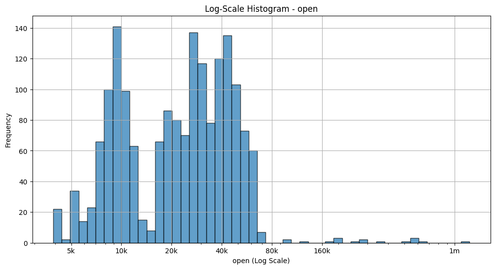

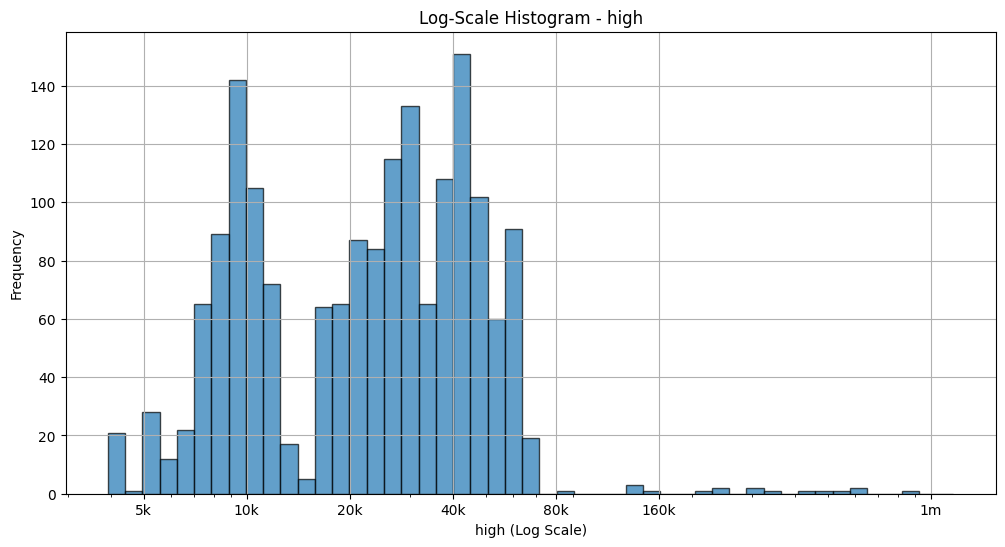

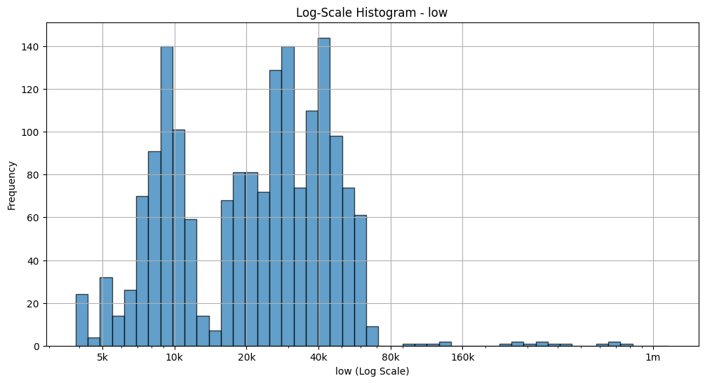

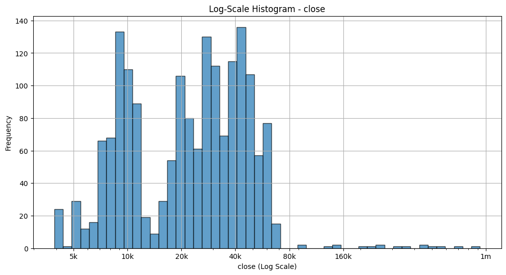

```
Generating Box Plots...
```

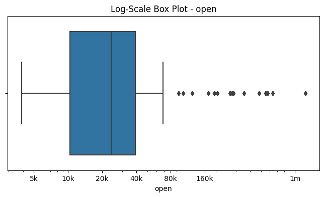

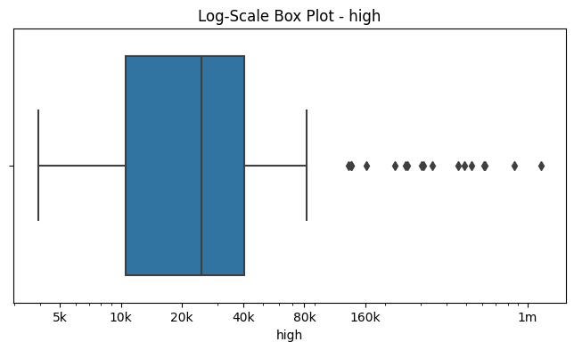

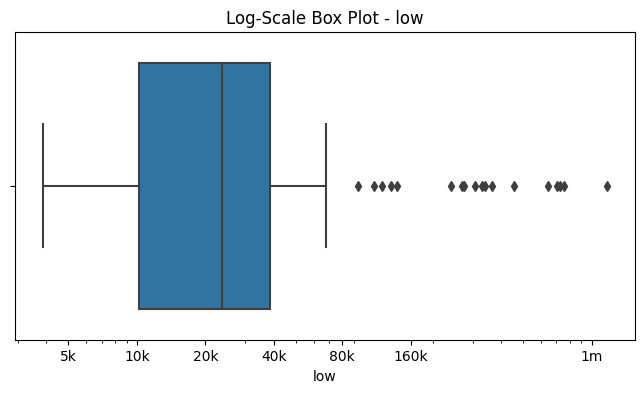

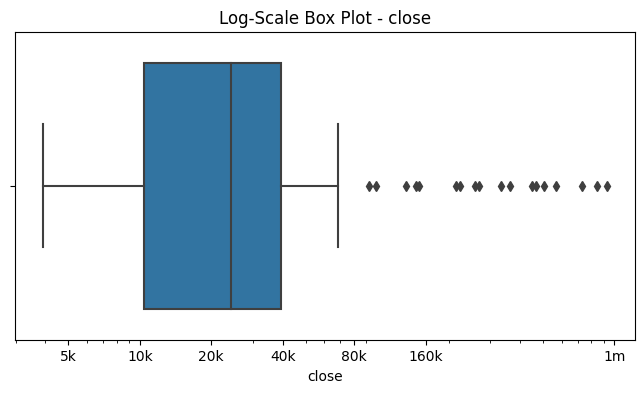

```python
# Assuming df_dirty is your original DataFrame
columns_of_interest = ['open', 'high', 'low', 'close']
df_filtered = df_dirty[columns_of_interest]

# Convert all data to numeric, coercing errors to NaN
df_filtered = df_filtered.apply(pd.to_numeric, errors='coerce')

# Now check and ensure all columns are numeric
print("\nData Types:")
print(df_filtered.dtypes)

# Display basic descriptive statistics
print("Descriptive Statistics:")
print(df_filtered.describe())

# Identify and display the count of missing values for each column
print("\nMissing Values per Column:")
missing_values_count = df_filtered.isnull().sum()
print(missing_values_count)

# Histograms for numeric data
print("\nPlotting Histograms with Logarithmic Binning...")
for col in columns_of_interest:
    plt.figure(figsize=(12, 6))
    # Calculate log-spaced bins
    data = df_filtered[col].dropna() + 1  # Adding 1 to shift data to positive values if necessary
    log_bins = np.logspace(np.log10(data.min()), np.log10(data.max()), 50)  # 50 log-spaced bins
    plt.hist(data, bins=log_bins, edgecolor='k', alpha=0.7)
    plt.xscale('log')  # Set the x-axis to a logarithmic scale

    # Define the custom ticks for the logarithmic scale
    ticks = [5000, 10000, 20000, 40000, 80000, 160000, 1000000]
    labels = ['5k', '10k', '20k', '40k', '80k', '160k', '1m']
    plt.xticks(ticks, labels)  # Set custom ticks and labels

    plt.title(f'Log-Scale Histogram - {col}')
    plt.xlabel(f'{col} (Log Scale)')
    plt.ylabel('Frequency')
    plt.grid(True)
    plt.show()


# Generating horizontal box plots for each column to visually inspect for outliers
print("\nGenerating Box Plots...")
for col in columns_of_interest:
    if df_filtered[col].dtype in ['float64', 'int64']:  # Check if the column is numeric
        plt.figure(figsize=(8, 4))  # Set the figure size for each individual plot

        # Adding a small constant to handle non-positive values before applying log scale
        data = df_filtered[col] + 1  # Adjust this based on the smallest value if necessary

        # Create the boxplot
        sns.boxplot(x=data, orient='h')

        # Set the x-axis to logarithmic scale
        plt.xscale('log', base=10)

        # Define the custom ticks for the logarithmic scale
        ticks = [5000, 10000, 20000, 40000, 80000, 160000, 1000000]
        labels = ['5k', '10k', '20k', '40k', '80k', '160k', '1m']
        plt.xticks(ticks, labels)  # Set custom ticks and labels

        plt.title(f'Log-Scale Box Plot - {col}')
        plt.show()
```

### Insights from Exploratory Data Analysis on Dirty Dataset (EDA)

#### Overview

The exploratory data analysis revealed several key insights into the dataset's structure and quality:

#### Key Observations

These insights are instrumental in guiding the subsequent data cleaning and preparation steps to ensure data quality and reliability for analysis and modeling.

### Cleaning the Introduced Noise from the Dataset

```python
# Step 1: Convert data to numeric, coercing errors for specific financial columns
columns_of_interest = ['open', 'high', 'low', 'close', 'volume']
for col in columns_of_interest:
    df_dirty[col] = pd.to_numeric(df_dirty[col], errors='coerce')

# Step 2: Convert the 'date' column to datetime, handling any format errors
df_dirty['date'] = pd.to_datetime(df_dirty['date'], errors='coerce')

# Step 3: Remove or replace outliers using IQR for the financial columns
for col in columns_of_interest:
    Q1 = df_dirty[col].quantile(0.25)
    Q3 = df_dirty[col].quantile(0.75)
    IQR = Q3 - Q1
    df_dirty = df_dirty[(df_dirty[col] >= (Q1 - 1.5 * IQR)) & (df_dirty[col] <= (Q3 + 1.5 * IQR))]

# Step 4: Fill null values with the median for the financial columns
for col in columns_of_interest:
    median = df_dirty[col].median()
    df_dirty[col].fillna(median, inplace=True)

# Step 5: Remove duplicate rows to ensure data uniqueness
df_dirty.drop_duplicates(inplace=True)

# Display cleaned data description only for the selected columns
print("\nCleaned Data Description for Selected Columns:")
print(df_dirty[columns_of_interest].describe())

# Print the data types of all columns after cleaning
print("\nData Types After Cleaning:")
print(df_dirty.dtypes)
```

```
Cleaned Data Description for Selected Columns:
           open      high       low     close            volume
count  1,329.00  1,329.00  1,329.00  1,329.00          1,329.00
mean  25,143.20 25,665.14 24,612.11 25,163.69 27,398,080,101.49
std   15,790.34 16,148.96 15,419.24 15,797.43 12,532,765,660.37
min    3,894.55  3,926.60  3,863.56  3,905.23  5,331,172,801.00
25%   10,143.80 10,295.67  9,855.48 10,138.52 17,595,377,311.00
50%   22,721.09 23,198.01 22,331.31 22,714.98 25,218,357,242.00
75%   37,469.16 38,366.11 36,581.43 37,536.63 34,971,338,710.00
max   68,299.26 68,673.05 68,053.12 68,498.88 65,210,059,683.00

Data Types After Cleaning:
date              datetime64[ns]
open                     float64
high                     float64
low                      float64
close                    float64
volume                   float64
rsi_7                    float64
rsi_14                   float64
cci_7                    float64
cci_14                   float64
sma_50                   float64
ema_50                   float64
sma_100                  float64
ema_100                  float64
macd                     float64
bollinger                float64
TrueRange                float64
atr_7                    float64
atr_14                   float64
next_day_close           float64
dtype: object
```

#### Outlier Handling

Outliers can significantly distort predictive analysis and risk modeling by creating biased or incorrect results.

- **Interquartile Range (IQR) Method**: Outliers were removed using the IQR method. This approach defines an 'outlier' based on the statistical spread of the data, removing any data points that lie beyond 1.5 times the IQR from the quartiles, ensuring the robustness of the dataset.

#### Duplicate Removal

- **Duplicate records were removed** to ensure the uniqueness of data, which is critical for maintaining the validity of the analysis.

# 3- Detailed Explanatory Data Analysis(EDA)

## 3.1 - Data Visualization and Comments

### Histograms for Numeric Values

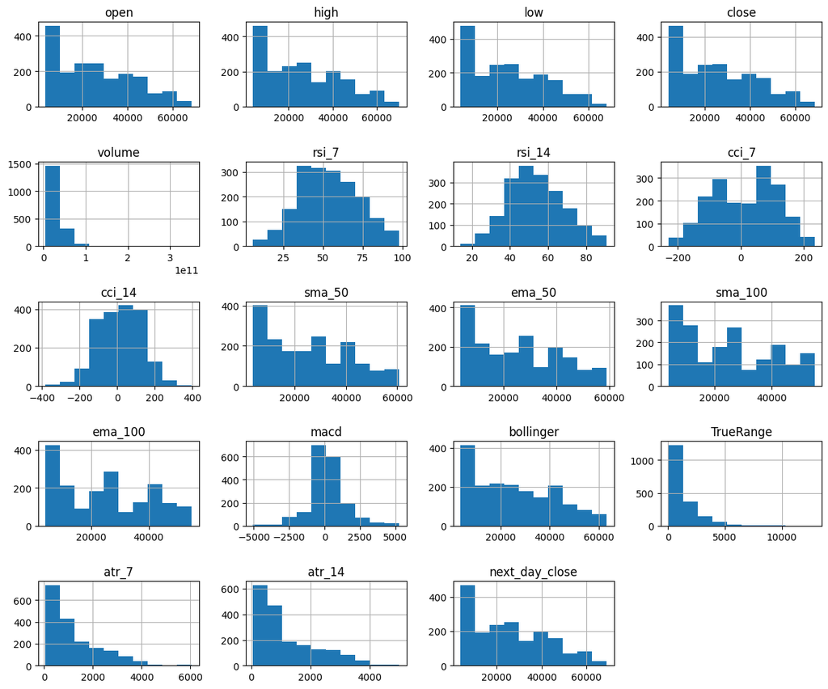

```python
# Select only the numeric columns, excluding 'date'
numeric_columns = df_bitcoin_2019_2024_selected.select_dtypes(include=[np.number])

# Plot histograms for the numeric columns
numeric_columns.hist(figsize=(12, 10))
plt.tight_layout()
plt.show()
```

### Detailed Insights on Cryptocurrency Indicators and Price Data

The histograms generated for the Bitcoin dataset provide a visual representation of the distribution and range of various technical indicators and price data. Understanding these can enhance the effectiveness of trading strategies by highlighting different market dynamics. These indicators and price data are utilized to identify potential buy or sell signals based on historical patterns, market volatility, and trading momentum. By understanding each component's behavior and interaction, traders can formulate more nuanced and informed trading decisions.

#### Trend Indicators

1. **Simple Moving Averages (SMA) and Exponential Moving Averages (EMA) 50 and 100:**
   - Range: 0 to the maximum observed price.
   - Usage: Identify long-term price trends. SMAs provide a smoothed average, while EMAs respond more quickly to price changes.
2. **Bollinger Bands:**
   - Components: Middle band (SMA of closing prices), upper and lower bands (standard deviations away from the SMA).
   - Usage: Measures market volatility. Prices near the upper band suggest overbought conditions, while those near the lower band indicate oversold conditions

#### Momentum Indicators

1. **Relative Strength Index (RSI) 7 and 14:**
   - Range: 0 to 100.
   - Usage: Identifies overbought (>70) or oversold (<30) conditions. Shorter periods (7 days) react more quickly to price changes than longer periods (14 days).
2. **Moving Average Convergence Divergence (MACD):**
   - Range: Can vary significantly, often from -5000 to +5000.
   - Usage: Shows the relationship between two moving averages of prices. MACD rising above the signal line is bullish, below is bearish.
3. **Commodity Channel Index (CCI) 7 and 14:**
   - Range: Typically between -200 and +200, but can vary.
   - Usage: Identifies cyclical trends. A value above +100 suggests a strong upward trend (overbought), and below -100 a strong downward trend (oversold).

#### Volatility Indicators

1. **Average True Range (ATR) 7 and 14:**
   - Range: Dependent on price range and volatility.
   - Usage: Measures market volatility. Higher ATR values indicate increased volatility, and vice versa.
2. **True Range:**
   - Range: Reflects the volatility within a single trading day.
   - Usage: Part of the calculation for ATR, providing insight into daily price variability.

#### Price Data

- **Open:** The price at the beginning of the trading interval
- **High:** The highest price during the trading interval.
- **Low:** The lowest price during the trading interval.
- **Close:** The price at the end of the trading interval.
- **Volume:** The number of shares or contracts traded in a security or an entire market during a given period.
- **Next Day Close:** The closing price of the next trading day.

### Bitcoin Price During the Selected Time Period

```python
def candle_chart(data,label):

    candlestick = go.Figure(data = [go.Candlestick(x=data.date,
                                                   open = data['open'],
                                                   high = data['high'],
                                                   low = data['low'],
                                                   close = data['close'])])
    candlestick.update_xaxes(title_text = 'Time',
                             rangeslider_visible = True,
                             tickformat='%Y-%m-%d')

    candlestick.update_layout(
    title = {
            'text': '{:} Candelstick Chart'.format(label),
            "y":0.8,
            "x":0.5,
            'xanchor': 'center',
            'yanchor': 'top'})

    candlestick.update_yaxes(title_text = 'Price in USD', ticksuffix = '$')
    return candlestick
candle=candle_chart(df_bitcoin_2019_2024_selected, label="BTC Price")
candle.show()
```

[interactive chart not shown]

### Founding the Outliers

```python
Q1 = df_bitcoin_2019_2024_selected['close'].quantile(0.25)
Q3 = df_bitcoin_2019_2024_selected['close'].quantile(0.75)
IQR = Q3 - Q1

# Define bounds for outliers
lower_bound = Q1 - 1.5 * IQR
upper_bound = Q3 + 1.5 * IQR

# Filter rows that are considered outliers based on the IQR method
outliers = df_bitcoin_2019_2024_selected[(df_bitcoin_2019_2024_selected['close'] < lower_bound) | (df_bitcoin_2019_2024_selected['close'] > upper_bound)]

if outliers.empty:
    print("\n\nThere are no outliers detected between 9th of March 2019 and 9th of March 2024!")
else:
    print("\nDetected Outliers at Selected Time Period: ")
    print(outliers)
```

```
There are no outliers detected between 9th of March 2019 and 9th of March 2024!
```

## Correlation Matrix

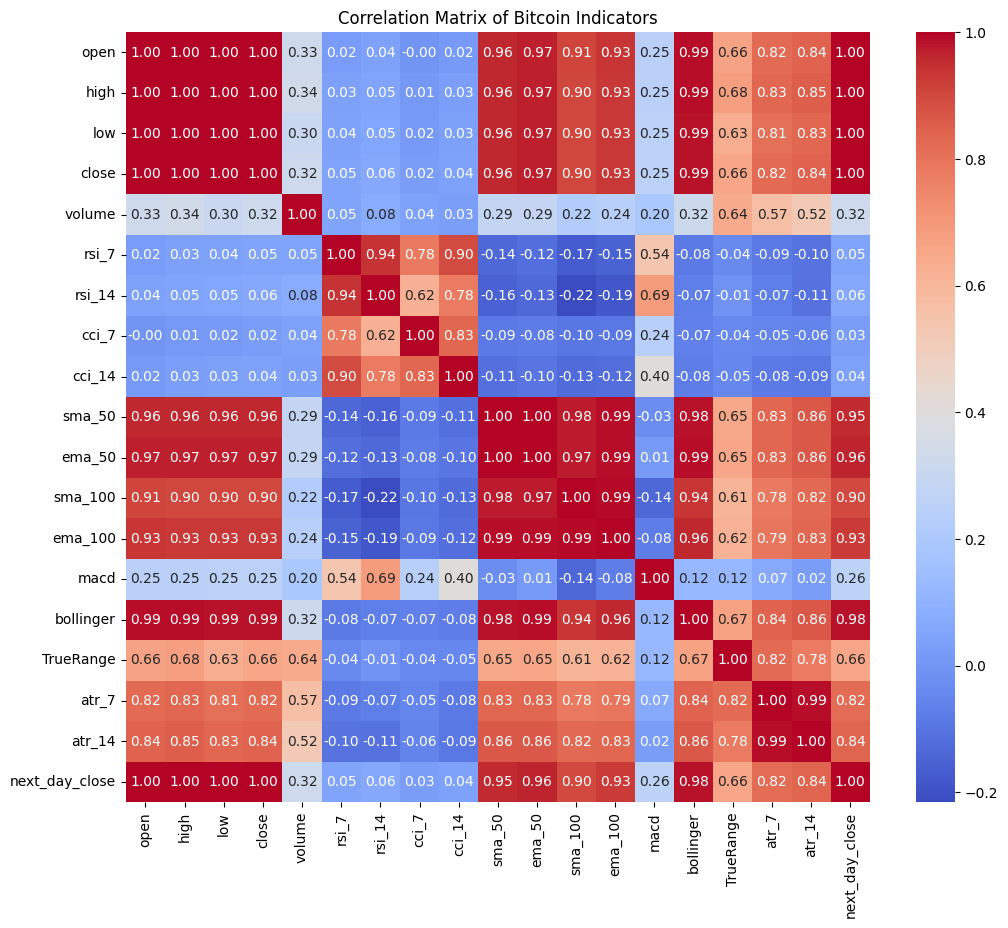

```python
corr_matrix = df_bitcoin_2019_2024_selected.corr()
plt.figure(figsize=(12, 10))
sns.heatmap(corr_matrix, annot=True, cmap='coolwarm',fmt=".2f")
plt.title("Correlation Matrix of Bitcoin Indicators")
plt.show()
```

#### Nature of Price Data:

- **Open, High, Low, Close (OHLC) Data**: These metrics are all directly related since they represent different aspects of the price within the same trading period. Therefore, it's typical to see strong correlations among them because they are all responses to the same market conditions within a given timeframe.
- **Derived Indicators**: Many technical indicators are derivatives of the price and/or volume. For example, `moving averages (SMA, EMA)`, `Bollinger Bands`, and `MACD` lines are calculated directly from price data, leading to naturally high correlations with the original price components.

### Understanding Correlations with OHLC (Open, High, Low, Close) Data

#### 1. **OHLC and Moving Averages (SMA, EMA)**

- **Direct Relationship**: As seen in the correlation matrix, moving averages (SMA and EMA) typically have a high positive correlation with Close prices, often above 0.9. This shows their role in smoothing out price fluctuations over time and reflecting the underlying trend.
- **Lag Effect**: During periods of high market volatility, the correlation between moving averages and daily prices might decrease slightly, indicating the lagging nature of SMA and EMA during rapid price changes.

#### 3. **OHLC and Volatility Indicators (e.g., Bollinger Bands, ATR)**

- **Volatility and Price Extremes**: Bollinger Bands show a distinct correlation pattern with High and Low prices in the correlation matrix, often reflected by correlation values near 0.8 or higher with High prices and similarly strong correlations with Low prices. This underscores the indicator’s utility in capturing price extremes.
- **ATR and Price Movements**: Average True Range (ATR) tends to have a strong positive correlation with the range of daily prices, as highlighted by correlation values often exceeding 0.7 in the matrix. This high correlation emphasizes ATR’s effectiveness in measuring market volatility and potential price breakout areas.

## Plot Bitcoin SMA and EMA

```python
data = df_bitcoin_2019_2024_selected.copy()
data.sort_index(inplace=True)

# Calculate bullish (golden) and bearish (death) crossovers for SMA
data['bullish_crossover_sma'] = ((data['sma_50'].shift(1) < data['sma_100'].shift(1)) & (data['sma_50'] >= data['sma_100']))
data['bearish_crossover_sma'] = ((data['sma_50'].shift(1) > data['sma_100'].shift(1)) & (data['sma_50'] <= data['sma_100']))


# Create traces for moving averages with custom hover templates
trace_sma_50 = go.Scatter(
    x=data['date'], y=data['sma_50'], mode='lines', name='SMA 50',
    line=dict(color='royalblue'),
    hovertemplate='<b>SMA 50</b>: %{y}<extra></extra>'
)
trace_sma_100 = go.Scatter(
    x=data['date'], y=data['sma_100'], mode='lines', name='SMA 100',
    hovertemplate='<b>SMA 100</b>: %{y}<extra></extra>'
)

trace_bullish_sma = go.Scatter(
    x=data[data['bullish_crossover_sma']]['date'],
    y=data[data['bullish_crossover_sma']]['sma_50'],
    mode='markers',
    marker=dict(color='green', size=10, symbol='triangle-up'),
    name='Bullish Crossover SMA (Golden Cross)',
    hovertemplate='<b>Bullish Crossover SMA</b><br>Date: %{x}<br>SMA 50: %{y}<extra></extra>'
)

trace_bearish_sma = go.Scatter(
    x=data[data['bearish_crossover_sma']]['date'],
    y=data[data['bearish_crossover_sma']]['sma_50'],
    mode='markers',
    marker=dict(color='red', size=10, symbol='triangle-down'),
    name='Bearish Crossover SMA (Death Cross)',
    hovertemplate='<b>Bearish Crossover SMA</b><br>Date: %{x}<br>SMA 50: %{y}<extra></extra>'
)

trace_price_line_sma = go.Scatter(
    x=data['date'],
    y=data['close'],
    mode='lines',
    name='Closing Price',
    line=dict(color='orange'),
    hovertemplate='<b>Closing Price</b>: %{y}<extra></extra>'
)

# Combine traces and create the figure for SMAs
fig_sma = go.Figure(data=[trace_price_line_sma, trace_sma_50, trace_sma_100, trace_bullish_sma, trace_bearish_sma])
fig_sma.update_layout(
    title='SMA 50 and SMA 100 Crossovers with Closing Price for Bitcoin',
    xaxis_title='Date',
    yaxis_title='Price',
    xaxis=dict(rangeslider_visible=True, tickformat='%Y-%m-%d'),
    hovermode='x unified'
)
fig_sma.show()
```

[interactive chart not shown]

#### Reminder of Indicators:

- **Simple Moving Averages (SMA) 50 and 100**: The SMA is a technical indicator that calculates the average of a selected range of prices, typically closing prices, over the specified number of periods. Here, SMA 50 represents the average closing price over the last 50 days, and SMA 100 over the last 100 days. SMAs smooth out price data by creating a constantly updated average price, which helps to identify trends.

#### Brief Overview of Signals:

- **Bullish Signals**:
  1. `Price Line Crosses Above SMA`: Occur when the price moves above the SMA, suggesting an uptrend as the current prices are higher than the average past prices.
  2. `Golden Cross`: This occurs when a shorter-term SMA (like SMA 50) crosses above a longer-term SMA (like SMA 100). It indicates that recent average prices are higher than past average prices, suggesting bullish momentum.
- **Bearish Signals**:
  1. `Price Line Crosses Below SMA`: Emerge when the price drops below key moving averages, suggesting downward price momentum and potentially prompting selling or short-selling activities.
  2. `Death Cross`: Occurs when a shorter-term SMA (like SMA 50) crosses below a longer-term SMA (like SMA 100). It indicates that recent average prices are lower than past average prices, suggesting bearish momentum.

#### Examples from the Graph:

- **Example of a Bullish Signal**:
  - **Date of Bullish Crossover**: August 19, 2021
    - On August 19, 2021, the SMA 50 crossed above the SMA 100, marking a bullish signal. The closing price on this date was 46.71k. From August 19, 2021, to September 6, 2021, Bitcoin increased from 46.71k to 52.63k, which is a significant price increase of approximately 12.68%.
- **Example of a Bearish Signal**:
  - **Date of Bearish Crossover**: December 27, 2021
    - On December 27, 2021, the SMA 50 crossed below the SMA 100, marking a bearish signal. The closing price on this date was 50.64k. From December 27, 2021, to January 10, 2022, the price of Bitcoin decreased from 50.64k to 41.82k, marking a significant decline of approximately 17.39%.

```python
data = df_bitcoin_2019_2024_selected.copy()
data.sort_index(inplace=True)

# Calculate bullish (golden) and bearish (death) crossovers for EMA
data['bullish_crossover_ema'] = ((data['ema_50'].shift(1) < data['ema_100'].shift(1)) & (data['ema_50'] >= data['ema_100']))
data['bearish_crossover_ema'] = ((data['ema_50'].shift(1) > data['ema_100'].shift(1)) & (data['ema_50'] <= data['ema_100']))

# Create traces for moving averages with custom hover templates
trace_ema_50 = go.Scatter(
    x=data['date'], y=data['ema_50'], mode='lines', name='EMA 50',
    line=dict(color='royalblue'),
    hovertemplate='<b>EMA 50</b>: %{y}<extra></extra>'
)
trace_ema_100 = go.Scatter(
    x=data['date'], y=data['ema_100'], mode='lines', name='EMA 100',
    hovertemplate='<b>EMA 100</b>: %{y}<extra></extra>'
)

trace_bullish_ema = go.Scatter(
    x=data[data['bullish_crossover_ema']]['date'],
    y=data[data['bullish_crossover_ema']]['ema_50'],
    mode='markers',
    marker=dict(color='green', size=10, symbol='triangle-up'),
    name='Bullish Crossover EMA (Golden Cross)',
    hovertemplate='<b>Bullish Crossover EMA</b><br>Date: %{x}<br>EMA 50: %{y}<extra></extra>'
)

trace_bearish_ema = go.Scatter(
    x=data[data['bearish_crossover_ema']]['date'],
    y=data[data['bearish_crossover_ema']]['ema_50'],
    mode='markers',
    marker=dict(color='red', size=10, symbol='triangle-down'),
    name='Bearish Crossover EMA (Death Cross)',
    hovertemplate='<b>Bearish Crossover EMA</b><br>Date: %{x}<br>EMA 50: %{y}<extra></extra>'
)

# Create line trace for the closing price
trace_price_line_ema = go.Scatter(
    x=data['date'],
    y=data['close'],
    mode='lines',
    name='Closing Price',
    line=dict(color='orange'),
    hovertemplate='<b>Closing Price</b>: %{y}<extra></extra>'
)

# Combine traces and create the figure for EMAs
fig_ema = go.Figure(data=[trace_price_line_ema, trace_ema_50, trace_ema_100, trace_bullish_ema, trace_bearish_ema])
fig_ema.update_layout(
    title='EMA 50 and EMA 100 Crossovers with Closing Price for Bitcoin',
    xaxis_title='Date',
    yaxis_title='Price',
    xaxis=dict(rangeslider_visible=True, tickformat='%Y-%m-%d'),
    hovermode='x unified'
)
fig_ema.show()
```

[interactive chart not shown]

#### Reminder of Indicator:

- **Exponential Moving Averages (EMA) 50 and 100**: Unlike the SMA, the EMA places greater weight and significance on the most recent data points. The EMA 50 and EMA 100 provide insights into the market's direction but react more quickly to recent price changes, making them more responsive than their SMA counterparts. This responsiveness makes the EMA particularly useful for identifying early signals of market turning points.

#### Brief Overview of Signals:

- **Bullish Signals**:
  1. `Price Line Crosses Above EMA`: When the price crosses above the EMA, it suggests that recent price gains are outpacing past averages, potentially signaling the start of a new uptrend.
  2. `Golden Cross`: Occurs when a shorter-term EMA (like EMA 50) crosses above a longer-term EMA (like EMA 100). It suggests increasing bullish sentiment as recent prices rise faster than past prices.
- **Bearish Signals**:
  1. `Price Line Crosses Below EMA`: When the price crosses below the EMA, it suggests that recent price losses are significant compared to past averages, potentially signaling the start of a new downtrend.
  2. `Death Cross`: Occurs when a shorter-term EMA crosses below a longer-term EMA. It suggests increasing bearish sentiment as recent prices fall faster than past prices.

#### Examples from the Graph:

- **Example of a Bullish Signal**:
  - **Date of Bullish Crossover**: August 19, 2021
    - On August 19, 2021, the EMA 50 crossed above the EMA 100, marking a bullish signal. The closing price on this date was 46.71k. From August 19, 2021, to September 6, 2021, Bitcoin increased from 46.71k to 52.63k, which is a significant price increase of approximately 12.68%.
- **Example of a Bearish Signal**:
  - **Date of Bearish Crossover**: On December 22, 2021, the EMA 50 crossed below the EMA 100, marking a bearish signal. The closing price on this date was 48.62k. From December 22, 2021, to January 8, 2022, the price of Bitcoin decreased from 48.62k to 41.73k, marking a significant decline of approximately 14.17%.

## Plot Close Price and Volume

```python
df = df_bitcoin_2019_2024_selected.reset_index()
init_notebook_mode(connected=True)
colors = px.colors.qualitative.Plotly

df_date = df['date'].unique()
close_avg = df.groupby('date')['close'].mean().rename('Closing Price')
vol_avg = df.groupby('date')['volume'].mean().rename('Volume')

fig = make_subplots(rows=2, cols=1, shared_xaxes=True)

# Closing Price Trace
fig.add_trace(go.Scatter(x=df_date, y=close_avg, mode='lines',
                         name='Closing Price', marker_color=colors[0], line=dict(width=2)),
              row=1, col=1)

# Volume Trace
fig.add_trace(go.Scatter(x=df_date, y=vol_avg, mode='lines',
                         name='Volume', marker_color=colors[1], line=dict(dash='dash')),
              row=2, col=1)

# Annotations for events with hover text
events = {
    "2019-04-26": "Bitfinex and Tether accused of covering up an $850 million loss by the New York Attorney General.",
    "2019-05-01": "Craig Wright filed multiple lawsuits against those denying his claim to be Satoshi Nakamoto.",
    "2019-06-18": "Facebook announces its planned cryptocurrency, Libra, drawing significant global regulatory attention.",
    "2020-03-12": "Bitcoin price crashes in line with global markets due to COVID-19, marking one of its worst declines.",
    "2020-05-11": "Bitcoin undergoes its third halving, reducing the block reward from 12.5 to 6.25 bitcoins.",
    "2020-09-16": "Kraken becomes the first cryptocurrency firm in the US to become a bank.",
    "2021-02-08": "Tesla buys $1.5 billion worth of Bitcoin and announces it will accept Bitcoin payments.",
    "2021-04-14": "Coinbase goes public through a direct listing on the NASDAQ.",
    "2021-05-18": "China intensifies its crackdown on cryptocurrency mining and trading.",
    "2023-03-10": "Silicon Valley Bank collapses, indirectly impacting the crypto market.",
    "2023-10-15": "A fake tweet about BlackRock causes temporary significant Bitcoin price fluctuations.",
    "2023-12-05": "Bitcoin's computing power reaches a record high, indicating strong network security and miner commitment.",
    "2024-02-25": "Javier Milei, known for his pro-Bitcoin stance, is elected President of Argentina, influencing Bitcoin's legal status discussions.",
    "2024-03-01": "The FASB announces new accounting rules that allow Bitcoin to be measured at fair value on corporate balance sheets.",
    "2024-03-08": "Increased Bitcoin transaction fees due to the popularity of Ordinals highlight network capacity issues."
}

for date, desc in events.items():
    event_date = pd.to_datetime(date)
    close_value = close_avg.loc[event_date] if event_date in close_avg.index else None
    if close_value:
        fig.add_annotation(
            x=date, y=close_value,
            xref="x", yref="y",
            text='.',
            showarrow=True,
            arrowhead=1,
            ax=0, ay=-40,
            font=dict(size=12, color="black"),
            bgcolor="white",
            opacity=0.8,
            hovertext= f"{date}<br>Closing Price: ${close_value:.2f}<br>{desc}",
            hoverlabel=dict(bgcolor="white", font_size=16, font_family="Rockwell"),
            arrowcolor="red"
        )

# Update Axes and Rangeslider
fig.update_xaxes(rangeslider_visible=True, row=2, col=1,
                 rangeselector=dict(
                     buttons=list([
                         dict(count=6, label="6m", step="month", stepmode="backward"),
                         dict(count=1, label="1y", step="year", stepmode="backward"),
                         dict(count=2, label="2y", step="year", stepmode="backward"),
                         dict(step="all")
                     ])))

# Update Layout
fig.update_layout(
    title='Closing Price and Volume with Event Markers',
    hovermode='x unified',
    height=800,
    yaxis1_title='Closing Price',
    yaxis2_title='Volume',
    legend_title='Data Type'
)

fig.show()
```

[interactive chart not shown]

#### Insights and Analysis:

- **Correlation between Price and Volume**: By examining the two plots together, one can look for correlations between price movements and trading volumes. Typically, significant changes in volume might precede or accompany price spikes or drops, providing predictive insights into potential price movements based on trading volume.
- **Market Activity**: Periods of high volume may indicate high interest or market stress, which could match with significant price changes, offering strategic insights for trading decisions.
- **Market Activity and Trader Behavior**:
  - Periods of sustained high volume may signal strong buyer or seller interest and potentially mark the beginning of new trends or the end of current ones. For example, a prolonged period of increased volume alongside a steady price rise could indicate a strong bullish sentiment, whereas similar volume during a price decline might suggest bearish conditions.
  - Volume patterns can also reveal periods of consolidation, where volume decreases as traders might be taking a wait-and-see approach during uncertain market conditions.

## Plot for Bitcoin Price with MACD Indicator

```python
# Calculate EMAs, MACD, Signal Line, and Histogram
df['EMA12'] = df['close'].ewm(span=12, adjust=False).mean()
df['EMA26'] = df['close'].ewm(span=26, adjust=False).mean()
df['Signal_Line'] = df['macd'].ewm(span=9, adjust=False).mean()

# Identify Crossovers
df['Crossover_Up'] = ((df['macd'].shift(1) < df['Signal_Line'].shift(1)) & (df['macd'] >= df['Signal_Line']))
df['Crossover_Down'] = ((df['macd'].shift(1) > df['Signal_Line'].shift(1)) & (df['macd'] <= df['Signal_Line']))

# Plotting the chart
fig = go.Figure()

# Add closing price trace
fig.add_trace(go.Scatter(x=df['date'], y=df['close'], mode='lines', name='Closing Price'))

# Add MACD trace
fig.add_trace(go.Scatter(x=df['date'], y=df['macd'], mode='lines', name='MACD'))

# Add Signal Line
fig.add_trace(go.Scatter(x=df['date'], y=df['Signal_Line'], mode='lines', name='Signal Line'))

# Highlighting Bullish Crossovers
fig.add_trace(go.Scatter(x=df[df['Crossover_Up']]['date'], y=df[df['Crossover_Up']]['macd'], mode='markers', marker=dict(color='green', size=5), name='Bullish Crossover'))

# Highlighting Bearish Crossovers
fig.add_trace(go.Scatter(x=df[df['Crossover_Down']]['date'], y=df[df['Crossover_Down']]['macd'], mode='markers', marker=dict(color='red', size=5), name='Bearish Crossover'))

# Add horizontal line at zero level of MACD
fig.add_trace(go.Scatter(x=df['date'], y=[0] * len(df), mode='lines', name='Zero Level', line=dict(color='black', width=1, dash='dash')))

# Update layout with rangeslider
fig.update_layout(
    title='Bitcoin Price with MACD Indicator',
    xaxis=dict(title='Date', rangeslider=dict(visible=True)),
    yaxis=dict(title='Price'),
    hovermode='x unified'
)

# Show plot
fig.show()
```

[interactive chart not shown]

#### Reminder of Indicator:

- **MACD (Moving Average Convergence Divergence)**: MACD is a trend-following momentum indicator that illustrates the relationship between two moving averages of a security’s prices. The indicator is comprised of two lines: the MACD line, which is the difference between the 12-day and 26-day exponential moving averages (EMAs), and the signal line, which is the 9-day EMA of the MACD line. The MACD helps identify trend direction, momentum, and potential reversals.
- **Signal Line**: The Signal Line is a smoother counterpart of the MACD Line and is its 9-day EMA. It acts as a trigger for MACD signals. The crossing of the MACD Line over the Signal Line suggests potential shifts in market momentum and direction, making it a crucial signal for traders.

#### Brief Overview of Signals:

- **Bullish Signals**:
  1. `MACD Line Crosses Above the Signal Line`: This is typically seen as a bullish signal, suggesting that the short-term momentum is strengthening relative to the long-term momentum. Traders might consider this as a buying opportunity
     - Visual: On a chart, this appears as the MACD Line crossing above the Signal Line.
  2. `MACD Line Rises Above Zero`: When the MACD Line crosses above the zero line, it indicates that the short-term average is above the long-term average, reinforcing bullish market conditions. This can be seen as a stronger confirmation of bullish conditions and might solidify the decision to hold or enter new long positions.
     - Visual: The MACD Line moves from negative to positive territory on the graph.
- **Bearish Signals**:
  1. `MACD Line Crosses Below the Signal Line`: This is generally viewed as a bearish signal, indicating that the short-term momentum is weakening compared to the long-term momentum. Traders might see this as an opportunity to sell or short-sell.
     - Visual: This appears as the MACD Line crossing below the Signal Line on the chart.
  2. `MACD Line Falls Below Zero` : A crossing below zero suggests that the short-term average has fallen below the long-term average, a sign of bearish market conditions. This may be considered a confirmation of bearish conditions, decisions to exit long positions or to initiate short positions.
     - Visual: The MACD Line transitions from positive to negative territory.

#### Examples from the Graph:

- **Example of a Bullish Signal**:
  - **Date of Bullish Crossover**: March 14, 2023
    - On March 15, 2023, the MACD line crossed above the Signal Line, marking a bullish signal. The closing price on this date was 24.37k. From March 15,2023 to April 2, 2023 Bitcoin increased from 24.37k to 28.19k which is a significant price increase of approximately 15.66%.
- **Example of a Bearish Signal**:
  - **Date of Bearish Crossover**: November 12, 2021
    - On November 14, 2021, the MACD line crossed below the Signal Line, marking a bearish signal. The closing price on this date was 65.46k. From November 14 to November 30, 2021, the price of Bitcoin decreased from 65.46k to 57k, marking a significant decline of approximately 12.94%.

#### Additional Insights

- **Divergence**: Pay attention to divergences where the price of a security is making new highs or lows that are not corroborated by the MACD. This can indicate potential reversals.
- **Responsiveness**: The MACD can be tailored by adjusting the time periods of the EMAs to fit different trading styles and sensitivity preferences.

## RSI 7, RSI 14 with Bollinger Middle Band

**RSI (7 and 14) + Bollinger Bands:** This combination can help identify overbought/oversold conditions along with volatility levels.

- Bollinger Bands consist of three lines: the middle band (typically a moving average), the upper band, and the lower band. The upper and lower bands are usually calculated as a certain number of standard deviations away from the middle band. Since I don't have the upper and lower band, I will calculate them.
- **Calculate Standard Deviation:** Calculate the standard deviation of the closing prices over a specified period. This period is often the same as the one used for calculating the moving average (middle band).
- **Upper Band:** Add the standard deviation multiplied by a factor (often 2) to the middle band.
- **Lower Band:** Subtract the standard deviation multiplied by the same factor from the middle band.

```python
import plotly.express as px

# Define color palette with better contrast
colors = px.colors.qualitative.Plotly  # Use other colors from Plotly's qualitative palette

# Calculate standard deviation
std_dev = df['close'].rolling(window=20).std()

# Calculate upper and lower bands
bollinger_upper = df['bollinger'] + 2 * std_dev
bollinger_lower = df['bollinger'] - 2 * std_dev

# Calculate signals
# Define combined signals
df['buy_signal'] = (df['close'] < bollinger_lower) & ((df['rsi_7'] < 30) | (df['rsi_14'] < 30))
df['sell_signal'] = (df['close'] > bollinger_upper) & ((df['rsi_7'] > 70) | (df['rsi_14'] > 70))

# Initialize figure with subplots
fig = make_subplots(rows=2, cols=1, shared_xaxes=True)

# Add Bollinger Bands traces
fig.add_trace(go.Scatter(x=df['date'], y=df['close'], mode='lines', name='Closing Price'), row=1, col=1)
fig.add_trace(go.Scatter(x=df['date'], y=df['bollinger'], mode='lines', name='Middle Band'), row=1, col=1)
fig.add_trace(go.Scatter(x=df['date'], y=bollinger_upper, mode='lines', name='Upper Band', line=dict(color='orange')), row=1, col=1)
fig.add_trace(go.Scatter(x=df['date'], y=bollinger_lower, mode='lines', name='Lower Band', line=dict(color='purple')), row=1, col=1)

# Add Bollinger Bands Buy and Sell signals
fig.add_trace(go.Scatter(x=df[df['buy_signal']]['date'], y=df[df['buy_signal']]['close'], mode='markers', marker=dict(color='green', size=7, symbol='triangle-up'), name='Buy Signal'), row=1, col=1)
fig.add_trace(go.Scatter(x=df[df['sell_signal']]['date'], y=df[df['sell_signal']]['close'], mode='markers', marker=dict(color='red', size=7, symbol='triangle-down'), name='Sell Signal'), row=1, col=1)

# Add RSI traces
fig.add_trace(go.Scatter(x=df['date'], y=df['rsi_7'], mode='lines', name='RSI 7', line=dict(color='purple')), row=2, col=1)
fig.add_trace(go.Scatter(x=df['date'], y=df['rsi_14'], mode='lines', name='RSI 14', line=dict(color='orange')), row=2, col=1)

# Add Combined Buy and Sell signals on RSI plot as well
fig.add_trace(go.Scatter(x=df[df['buy_signal']]['date'], y=df[df['buy_signal']]['rsi_7'], mode='markers', marker=dict(color='green', size=7, symbol='triangle-up'), name='Combined Buy Signal'), row=2, col=1)
fig.add_trace(go.Scatter(x=df[df['sell_signal']]['date'], y=df[df['sell_signal']]['rsi_7'], mode='markers', marker=dict(color='red', size=7, symbol='triangle-down'), name='Combined Sell Signal'), row=2, col=1)

# Update layout
fig.update_layout(
    title='Bitcoin Trading Signals with Bollinger Bands and RSI',
    xaxis_title='Date',
    yaxis_title='Price',
    showlegend=True,
    hovermode='x unified'
)

# Show figure
fig.show()
```

[interactive chart not shown]

The combination of Bollinger Bands and RSI provides traders with powerful tools to identify potential buy or sell opportunities based on observed market conditions. By analyzing these indicators together, traders can make informed decisions about when to enter or exit trades, enhancing their strategies with detailed market analysis.  
Bollinger Bands measure market volatility and price levels relative to previous trades, while RSI focuses on the velocity and magnitude of directional price movements. Together, they offer a fuller picture of market dynamics. And also, each indicator on its own can sometimes give false signals. Combining them can help filter out noise by requiring confirmation from two independent measures before acting.

Using Bollinger Bands together with RSI allows traders to cross-verify signals, reducing false positives and enhancing the confidence in trading decisions. This strategy leverages the strength of both indicators—volatility and momentum—to offer a more nuanced view of market trends and potential turning points.

### Reminder of Indicators:

- **Bollinger Bands**: Comprised of three lines — a middle band which is a simple moving average (typically 20-day SMA), and two outer bands that represent standard deviations above and below the middle band. Bollinger Bands help gauge market volatility and price levels that may indicate overbought or oversold conditions.
- **RSI (Relative Strength Index)**: RSI is a momentum oscillator that measures the speed and change of price movements on a scale from 0 to 100. An RSI above 70 suggests overbought conditions, while below 30 may indicate oversold conditions.

### Brief Overview of Signals:

- **Bollinger Bands Signals**:
  - **Bullish**: When the price hits the lower band and rebounds, indicating a potential price increase from oversold conditions.
  - **Bearish**: When the price touches the upper band and recedes, suggesting a potential price decrease from overbought conditions.
- **RSI Signals**:
  - **Bullish**: An RSI value rising from below 30 typically indicates a turning point where prices might start to increase.
  - **Bearish**: An RSI value falling from above 70 suggests that the asset might begin to decrease in price.
- **Combined Signals:**:
  - **Bullish**: A strong bullish signal occurs when the price hits or crosses below the lower Bollinger Band while the RSI is below 30. This combination suggests that not only is the asset oversold according to Bollinger Bands, but the momentum is also strongly in favor of a price increase, highlighting a robust buying opportunity.
  - **Bearish**: A bearish signal is recognized when the price touches or exceeds the upper Bollinger Band while the RSI exceeds 70. This scenario indicates an overbought condition under both the volatility and momentum frameworks, suggesting a likely price decrease and potentially a good selling point.

# 4- Preparing to Model/Preprocessing

```python
# Load historical data
df = df_bitcoin_2019_2024_selected.copy()
df.set_index('date', inplace=True)
```

Here, firstly I copied the dataset to ensure that any modifications do not affect the original dataset. Then, the 'date' column is set as the index of the DataFrame, optimizing data retrieval and enabling time-based indexing essential for subsequent time-series operations.  
By setting the 'date' column as the DataFrame's index with `df.set_index('date', inplace=True)`, I am ensuring that the data is chronologically organized(Instead of dates being random), which is essential for time-series analysis. This makes the dataset more manageable for operations like querying by date, and visualization, where data is typically plotted against time. `This ordering is essential for training models on historical data to predict future trends accurately, since many models rely on the sequence of data points to make forecasts.`

## 4.1- Machine Learning Algorithm and Feature Selection

### Machine Learning Algorithm Selection

In this part of the analysis, `I am aiming to identify the best combination of technical indicators that can predict whether the next day's closing price will be higher than the current day's close`. To achieve this, I am using a RandomForestClassifier, a versatile and powerful machine learning model known for its ability to handle non-linear relationships and feature interactions effectively. I have also tried models like ARIMA(Autoregressive Integrated Moving Average), SARIMA (Seasonal ARIMA) and SVM(Support Vector Machine) but I achieved the most accuracy with RandomForestClassifier.

#### Why RandomForestClassifier Performed Better:

1. **Handling Non-Linear Relationships**: Unlike ARIMA and SARIMA, which are linear models, RandomForest can capture non-linear interactions between features, making it more suitable for complex datasets like cryptocurrency prices.
2. **Feature Interactions**: RandomForest is good at identifying interactions between features, which is crucial when dealing with multiple technical indicators that may have interdependent effects on the target variable.
3. **Robustness to Overfitting**: By averaging the results of multiple decision trees, RandomForest reduces the risk of overfitting compared to single decision tree models. This is particularly beneficial when dealing with volatile and noisy data like cryptocurrency prices.
4. **Versatility and Stability**: RandomForest is less sensitive to hyperparameter tuning and performs consistently well across different datasets and problem domains.

#### Pros of RandomForestClassifier:

- **Non-Linearity**: Can model complex, non-linear relationships.
- **Feature Importance**: Provides insights into feature importance, helping to understand which indicators are most influential.
- **Robustness**: Reduces overfitting through ensemble learning, providing stable and reliable predictions.
- **Handling High-Dimensional Data**: Performs well with large feature sets and can handle irrelevant or redundant features effectively.
- **Minimal Data Preprocessing**: Requires less data preprocessing compared to models like SVM or linear models.

#### Cons of RandomForestClassifier:

- **Interpretability**: RandomForest models can be complex and less transparent, making it harder to interpret individual decisions compared to simpler models like ARIMA.
- **Computationally Intensive**: Training can be resource-intensive, especially with large datasets and a high number of trees.
- **Slower Predictions**: Can be slower at making predictions compared to simpler models, which might be a consideration in real-time trading systems.
- **Memory Usage**: Requires more memory for training and storing the forest of trees, which can be a limitation on systems with restricted resources.

### Feature Selection

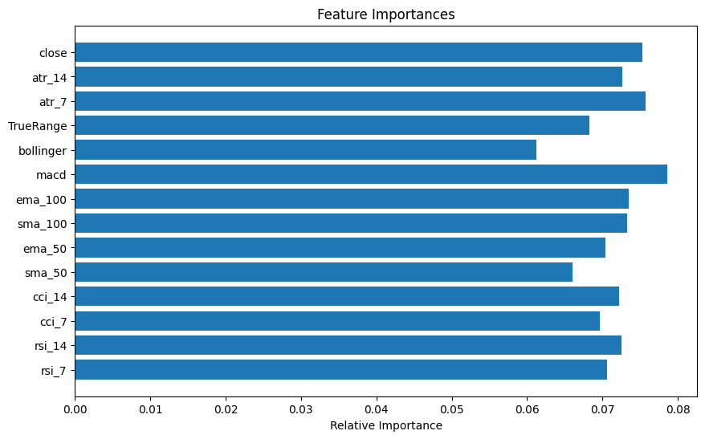

```python
from sklearn.ensemble import RandomForestClassifier
from sklearn.model_selection import TimeSeriesSplit

# Create a copy of the dataset for feature importance calculation so, it does not effect the actual training
df_copy = df.copy()

# Prepare target variable for the copied dataset
y_copy = df_copy['next_day_close'].shift(-1) > df_copy['close']

# Drop the last row with NaN value created by the shift
df_copy = df_copy[:-1]
y_copy = y_copy[:-1]

# Features to be used
features = ['rsi_7', 'rsi_14', 'cci_7', 'cci_14', 'sma_50', 'ema_50', 'sma_100', 'ema_100', 'macd', 'bollinger', 'TrueRange', 'atr_7', 'atr_14', 'close']

# Use TimeSeriesSplit for cross-validation
tscv = TimeSeriesSplit(n_splits=5)

# Initialize a list to hold feature importances from each split
importances_list = []

# Iterate over each training/test split generated by TimeSeriesSplit
for train_index, test_index in tscv.split(df_copy):
    # Select the training data based on the indices provided by the split
    X_train, y_train = df_copy.iloc[train_index][features], y_copy.iloc[train_index]

    # Initialize the RandomForest model
    model = RandomForestClassifier(n_estimators=100, random_state=42)
    # Train the model
    model.fit(X_train, y_train)
    # Append the feature importances from this split
    importances_list.append(model.feature_importances_)

# Average the importances over all splits
importances = pd.DataFrame(importances_list, columns=features).mean()

# Plot feature importances
plt.figure(figsize=(10, 6))
plt.title("Feature Importances")
plt.barh(range(len(features)), importances, align="center")
plt.yticks(range(len(features)), features)
plt.xlabel("Relative Importance")
plt.show()
```

#### Feature Importance Analysis and Stakeholder Consultation

The feature importance plot revealed that most features had relative importance values clustered between 0.06 and 0.08. Specifically, the least important feature was `bollinger` with a value close to 0.06, while the most important feature was `macd` with a value close to 0.08. Given the close range of these importance scores, it was challenging to decisively eliminate or select features based solely on their relative importance.

So, on this situation I decided to ask to my stakeholder and get consultation about his expertise in selecting the appropriate features. My stakeholder provided the following insights:

- **Exclusion of `sma_100` and `ema_100`**: These indicators were not favored by my stakeholder due to their long forecasting periods, which might not be as useful for the current analysis.
- **Exclusion of `TrueRange`**: My stakeholder said that he does not use `TrueRange` much. Although `TrueRange` is a volatility indicator, it was deemed redundant given that both `ATR` and `bollinger` serve as volatility indicators. Therefore, `TrueRange` was excluded from the feature set.
- **Retention of `bollinger`**: Despite `bollinger` having the lowest relative importance, my stakeholder mentioned that he uses this indicator extensively. The close relative importance values with `ATR` also justified retaining it for the best feature combination check.  
  Since we couldn't make a decision on indicators by ourselves based on exploratory data analysis (EDA), we agreed to just eliminate some and find the best combination by iterating and combining all of them with each other.

```python
from sklearn.ensemble import RandomForestClassifier
from sklearn.metrics import accuracy_score, classification_report
from sklearn.model_selection import TimeSeriesSplit
import itertools

features = ['rsi_7', 'rsi_14', 'cci_7', 'cci_14', 'sma_50', 'bollinger', 'ema_50', 'macd', 'atr_7', 'atr_14', 'close']
# The target variable y is a binary indicator(is like a yes-or-no answer), representing whether the next day’s close is higher than today’s.
y = df['next_day_close'].shift(-1) > df['close']

#I use TimeSeriesSplit for cross-validation, which is specifically designed for time-series data.
#This method ensures that the validation of the model respects the chronological order of observations.
tscv = TimeSeriesSplit(n_splits=5)

# Variables to track the best model's accuracy and its corresponding features
best_accuracy = 0
best_features = None

# Iterate over each training/test split generated by TimeSeriesSplit
for train_index, test_index in tscv.split(df):
    # Select the training and test data based on the indices provided by the split
    X_train, X_test = df.iloc[train_index][features], df.iloc[test_index][features]
    y_train, y_test = y.iloc[train_index], y.iloc[test_index]

    # Loop through each possible number of features to use in the model
    for r in range(1, len(features) + 1):
        # Generate and test each combination of 'r' features
        for feature_combination in itertools.combinations(features, r):
            # Initialize the RandomForest model
            model = RandomForestClassifier(n_estimators=100, random_state=42)
             # Train the model on the selected feature combination
            model.fit(X_train[list(feature_combination)], y_train)
            # Predict the test set outcomes
            y_pred = model.predict(X_test[list(feature_combination)])
            # Calculate the accuracy of the predictions
            accuracy = accuracy_score(y_test, y_pred)

             # Update the best accuracy and features if the current model performs better
            if accuracy > best_accuracy:
                best_accuracy = accuracy
                best_features = feature_combination

# After all combinations are tested, print the best performing model's details
print("Best Accuracy:", best_accuracy)
print("Best Feature Combination:", best_features)
print(classification_report(y_test, y_pred))
```

```
Best Accuracy: 0.631578947368421
Best Feature Combination: ('cci_14', 'macd', 'atr_7', 'atr_14')
              precision    recall  f1-score   support

       False       0.45      0.65      0.53       137
        True       0.55      0.35      0.43       167

    accuracy                           0.49       304
   macro avg       0.50      0.50      0.48       304
weighted avg       0.51      0.49      0.48       304
```

### Continued Strategy and Model Optimization

- As I mentioned before, after evaluating various models, including ARIMA, SARIMA, and SVM, I found that the RandomForestClassifier yielded the highest accuracy for predicting Bitcoin price movements. So, I will not try to improve my accuracy via trying another one. Consequently, I will continue using RandomForestClassifier along with the selected feature combination ('cci_14', 'macd', 'atr_7', 'atr_14') that previously achieved the best results.
- **Hyperparameter Tuning**: To further improve accuracy, I plan to focus on hyperparameter tuning. By adjusting parameters such as the number of trees, tree depth, and leaf requirements within the RandomForest model, I aim to optimize the model's performance without altering the underlying feature set. `This approach involves using GridSearchCV to systematically explore a range of parameter values, ensuring the selection of the most effective configuration for our specific data`.

```python
# Define features and target variable
X = df[['cci_14', 'macd', 'atr_7', 'atr_14']]
y = df['next_day_close'].shift(-1) > df['close'] # Predict if next day's close is higher
```

## 4.2- Spliting Into Train/Test

```python
# from sklearn.model_selection import TimeJsonSplit

# Initialize TimeSeriesSplit
tscv = TimeSeriesSplit(n_splits=5)

# Use TimeSeriesSplit to dynamically create training and testing sets that respect the time order
for train_index, test_index in tscv.split(X):
    X_train, X_test = X.iloc[train_index], X.iloc[test_index]
    y_train, y_test = y.iloc[train_index], y.iloc[test_index]

    # Optionally print details for each fold to inspect the split
    print("Training set length:", len(X_train), "Testing set length:", len(X_test))

# # Determine the split point for the training and test sets
# # Here, I decide to use 80% of the data for training and the remaining 20% for testing.
# split_idx = int(len(X) * 0.8)

# # Split the feature data into training and testing sets using the calculated index
# X_train, X_test = X.iloc[:split_idx], X.iloc[split_idx:]

# # Split the target data into training and testing sets in the same way
# y_train, y_test = y.iloc[:split_idx], y.iloc[split_idx:]

# print("There are in total", len(X), "observations, of which", len(X_train), "are now in the train set, and", len(X_test), "in the test set.")
```

```
Training set length: 307 Testing set length: 304
Training set length: 611 Testing set length: 304
Training set length: 915 Testing set length: 304
Training set length: 1219 Testing set length: 304
Training set length: 1523 Testing set length: 304
```

In predictive modeling, especially for financial time-series data like Bitcoin prices, `maintaining the chronological order of data is crucial. This ensures that the model's training and testing phases simulate real-world scenarios, where only past data is available to predict future events.` Here’s how we achieve this with `TimeSeriesSplit`:

1. **Maintain Historical Order**:
   - Instead of using a static split point, I utilize `TimeSeriesSplit`, which divides the dataset into several training and testing segments while preserving the time order. This approach ensures that all data points in the training set chronologically precede those in the test set, effectively eliminating the risk of information leakage from future data points.
2. **Determining the Split Point**:
   - `TimeSeriesSplit` dynamically calculates the indices for each split, adjusting the amount of data in training and testing sets across multiple iterations. This method allows the model to train on progressively larger sets of past data, which is critical for capturing long-term trends and seasonal patterns in Bitcoin price movements.
3. **Applying the Split**:
   - In each iteration, the dataset is divided into training and testing sets based on the indices calculated by `TimeSeriesSplit`. This ensures that each training set is strictly composed of data points that occur before the corresponding testing set. The sequential split not only strengthens the model's ability to forecast under realistic constraints but also tests its performance across different periods.

Using `TimeSeriesSplit` enhances my model’s reliability by training and evaluating it in a manner that mirrors its expected use in real-world financial forecasting, where predictions are always based on past observations.

## 4.3- Modelling/Model Selection

```python
from sklearn.metrics import accuracy_score, classification_report

# Initialize TimeSeriesSplit with 5 folds
tscv = TimeSeriesSplit(n_splits=5)

# Initialize the RandomForest model with 100 trees and a fixed random state for reproducibility
model = RandomForestClassifier(n_estimators=100, random_state=42)

# Variable to store the cumulative accuracy to calculate the average later
cumulative_accuracy = 0

# Use TimeSeriesSplit to create training and testing sets that respect the time order
for fold, (train_index, test_index) in enumerate(tscv.split(X)):
    X_train, X_test = X.iloc[train_index], X.iloc[test_index]
    y_train, y_test = y.iloc[train_index], y.iloc[test_index]

    # Train the RandomForest model
    model.fit(X_train, y_train)

    # Predict on the test set
    y_pred = model.predict(X_test)

    # Calculate and print accuracy for the current fold
    accuracy = accuracy_score(y_test, y_pred)
    cumulative_accuracy += accuracy
    print(f"Fold {fold+1}:")
    print(f"  Training set length: {len(X_train)}")
    print(f"  Testing set length: {len(X_test)}")
    print(f"  Accuracy: {accuracy:.2f}")

# Calculate and print the average accuracy over all folds
average_accuracy = cumulative_accuracy / 5
print(f"\nAverage Accuracy across all folds: {average_accuracy:.2f}")
```

```
Fold 1:
  Training set length: 307
  Testing set length: 304
  Accuracy: 0.62
Fold 2:
  Training set length: 611
  Testing set length: 304
  Accuracy: 0.49
Fold 3:
  Training set length: 915
  Testing set length: 304
  Accuracy: 0.47
Fold 4:
  Training set length: 1219
  Testing set length: 304
  Accuracy: 0.48
Fold 5:
  Training set length: 1523
  Testing set length: 304
  Accuracy: 0.56

Average Accuracy across all folds: 0.52
```

### Time Series Model Training Using RandomForestClassifier

#### Model and Cross-Validation Setup

- **TimeSeriesSplit**: We use `TimeSeriesSplit` with 5 folds for model validation, ideal for time-series data. This technique ensures chronological integrity, keeping training data before testing data and avoiding data leakage.
- **RandomForest Model**: The RandomForest is initialized with 100 trees (`n_estimators=100`) and a fixed random state (`random_state=42`) to ensure consistent results. This setup is used for initial modeling to gauge the base performance of our model across different periods.

#### Initial Results and Future Steps

- **Accuracy Reporting**: I am reporting the accuracy for each fold and calculate the average accuracy across all folds. This provides an initial look at how the model performs with the current parameters and setup.
- **Planned Hyperparameter Tuning**: Although the current results help establish a baseline, the next step involves hyperparameter tuning. I will systematically explore different parameter settings using techniques like `GridSearchCV` to enhance the model’s accuracy and robustness. This will allow us to fine-tune the model to better capture the underlying patterns in the data.

## Improving the Accuracy with Hyperparameter Tuning

```python
from sklearn.model_selection import GridSearchCV
from sklearn.ensemble import RandomForestClassifier
from sklearn.metrics import accuracy_score, classification_report
from sklearn.model_selection import TimeSeriesSplit

# TimeSeriesSplit for cross-validation to respect the chronological order of data
tscv = TimeSeriesSplit(n_splits=5)

# Define the RandomForest model and the range of parameters to be tuned
model = RandomForestClassifier(random_state=42)
parameters = {
    'n_estimators': [50, 100, 200],     # Number of trees in the forest
    'max_depth': [None, 10, 20, 30],    # Maximum depth of each tree
    'min_samples_split': [2, 5, 10],    # Minimum number of samples required to split an internal node
    'min_samples_leaf': [1, 2, 4]       # Minimum number of samples required to be at a leaf node
}

# Set up GridSearchCV to find the best parameters for the model using the specified TimeSeriesSplit
grid_search = GridSearchCV(estimator=model, param_grid=parameters, cv=tscv, scoring='accuracy')
grid_search.fit(X, y)

# Output the best model found from the grid search
best_model = grid_search.best_estimator_

# Evaluate the best model using the last fold from TimeSeriesSplit
train_index, test_index = list(tscv.split(X))[-1]
X_train, X_test = X.iloc[train_index], X.iloc[test_index]
y_train, y_test = y.iloc[train_index], y.iloc[test_index]

y_pred = best_model.predict(X_test)
print("Improved Accuracy:", accuracy_score(y_test, y_pred))
print("Best Parameters:", grid_search.best_params_)
```

```
Improved Accuracy: 0.8914473684210527
Best Parameters: {'max_depth': 10, 'min_samples_leaf': 1, 'min_samples_split': 2, 'n_estimators': 100}
```

### Hyperparameter Tuning Using GridSearchCV with TimeSeriesSplit

To optimize our RandomForestClassifier for predicting Bitcoin price movements, we employ `GridSearchCV` combined with `TimeSeriesSplit`. This approach allows us to fine-tune model parameters while ensuring that our time-series data is handled in a chronologically correct manner.

#### Why GridSearchCV?

`GridSearchCV` systematically works through multiple combinations of parameter tunes, cross-validating as it goes to determine which parameters yield the best model performance. The "CV" in GridSearchCV stands for cross-validation, ensuring that each hyperparameter combination is carefully evaluated using the method defined by the `cv` parameter—in this case, `TimeSeriesSplit`.

#### Configuration of GridSearchCV:

- **Parameters Tuned**:
  - `n_estimators`: The number of trees in the forest. We test with 50, 100, and 200 trees to understand the effect of tree quantity on model performance.
  - `max_depth`: Controls the maximum depth of each tree. Deeper trees can learn more detailed data specifics, increasing the risk of overfitting. We test several depths to find a balanced depth.
  - `min_samples_split`: The minimum number of samples a node must have before it can split. Higher numbers prevent the model from learning overly specific patterns.
  - `min_samples_leaf`: The minimum number of samples a leaf node must have. Increasing this number can smooth the model's predictions.
- **Cross-Validation Setup**: `TimeSeriesSplit` with 5 folds ensures that the model's validation process respects the chronological order of the dataset, a crucial aspect of time-series analysis.

These parameters suggest a model that balances the ability to generalize with the need to capture enough detail to make accurate predictions.

#### Why These Parameters Improve Performance:

- **`max_depth`: 10**
  - **Control Overfitting**: Prevents trees from becoming too complex and tailored to training data.
  - **Balanced Complexity**: Achieves a balance between complexity and generalization.
- **`min_samples_leaf`: 1**
  - **Maximum Detail**: Captures detailed patterns, crucial for volatile markets.
  - **Fine-Grained Splitting**: Allows for more detailed decision trees.
- **`min_samples_split`: 2**
  - **Flexibility in Splitting**: Enables splits with at least two samples, capturing detailed structures.
  - **Capturing Early Patterns**: Helps in identifying not obvious but important patterns early.
- **`n_estimators`: 100**
  - **Ensemble Strength**: More trees lead to better performance by averaging out noise.
  - **Stability and Consistency**: Ensures stable and consistent predictions across different data subsets.

## 4.4- Model Evaluation/Evaluation Metrics

### Precision, Recall(Sensitivity), F1

```python
from sklearn.metrics import precision_score,  recall_score, f1_score

# Evaluate precision
precision = precision_score(y_test, y_pred)
print("Precision:", precision)

# Evaluate recall
recall = recall_score(y_test, y_pred)
print("Recall (Sensitivity):", recall)

# Evaluate F1-score
f1 = f1_score(y_test, y_pred)
print("F1-score:", f1, '\n')

print(classification_report(y_test, y_pred))
```

```
Precision: 0.8594594594594595
Recall (Sensitivity): 0.9578313253012049
F1-score: 0.905982905982906

              precision    recall  f1-score   support

       False       0.94      0.81      0.87       138
        True       0.86      0.96      0.91       166

    accuracy                           0.89       304
   macro avg       0.90      0.88      0.89       304
weighted avg       0.90      0.89      0.89       304
```

**Classification Report**:

- **Precision**: About 94% for 'False' and 86% for 'True', indicating a high likelihood that the model's predictions are correct when it predicts an increase or decrease.
  - For 'False' (94%): This is the accuracy of the model's predictions when it predicts a price will not increase. It reflects the proportion of instances classified as not increasing that were actually not increasing.
  - For 'True' (86%): This is the accuracy of the model's predictions when it predicts a price will increase. It indicates how often the price actually increased when the model said it would.
- **Recall**: At 81% for 'False' and 96% for 'True', the model is quite capable of detecting the actual instances of each class.
  - For 'False' (81%): This shows the ability of the model to identify all actual instances of no price increase. It means that the model correctly identifies 81% of all the days when the price did not increase.
  - For 'True' (96%): This measures the model's ability to identify all actual increases. It tells us that the model correctly identifies 96% of all the days when the price increased.
- **F1-Score**: These scores (87% for 'False', 91% for 'True') balance precision and recall, suggesting a well-rounded model.
  - For 'False' (87%): A balanced score that takes into account the precision and recall for predictions of no price increase, suggesting good overall accuracy for this class.
  - For 'True' (91%): Similarly, this score balances precision and recall for predictions of a price increase, indicating strong performance for this prediction.

## 4.5- Simulating the Trade Stradegy

### Explanation of Trading Strategy Using CCI, MACD, and ATR

In the strategy outlined, I used a combination of three popular technical indicators: Commodity Channel Index (CCI), Moving Average Convergence Divergence (MACD), and Average True Range (ATR). These indicators are employed to identify potential buy and sell opportunities based on market conditions such as momentum, market sentiment, and volatility. Here’s how each indicator is used:

**Commodity Channel Index (CCI)**:

- CCI is used to detect when an asset is overbought (> +100) or oversold (< -100). These levels indicate that the price could soon revert back to the mean.

**Moving Average Convergence Divergence (MACD)**:

**Average True Range (ATR)**:

- ATR measures market volatility. A decrease in ATR from one period to the next (atr_7 < atr_7_prev) typically suggests that the market is becoming less volatile, which might indicate a stabilizing trend that makes entry or exit more appealing depending on the direction signaled by CCI and MACD.

```python
def generate_buy_signal(row):
    # Buy when CCI indicates oversold, MACD is positive indicating upward momentum,
    # and a decrease in ATR indicates lower market volatility
    return (row['cci_14'] < -100 and
            row['macd'] > 100 and
            row['atr_7'] < row['atr_7_prev'])

def generate_sell_signal(row):
    # Sell when CCI indicates overbought, MACD is negative indicating downward momentum,
    # and a decrease in ATR may suggest a decrease in volatility and potential reversal
    return (row['cci_14'] > 100 and
            row['macd'] < -100 and
            row['atr_7'] < row['atr_7_prev'])

# Calculate previous ATR values
df['atr_7_prev'] = df['atr_7'].shift(1)

# Apply buy and sell signal functions to the dataset
df['buy_signal'] = df.apply(generate_buy_signal, axis=1)
df['sell_signal'] = df.apply(generate_sell_signal, axis=1)

# Drop the 'atr_7_prev' column as it's no longer needed
df.drop('atr_7_prev', axis=1, inplace=True)
```

#### Buy and Sell Signal Logic:

- **Buy Signal**: The conditions for a buy signal include:
  - **CCI indicates oversold**: CCI indicating the asset is oversold (cci_14 < -100), which might suggest the asset's price is below what is typical and could increase. This is generally interpreted as a market condition where prices may be considered low relative to their average, and thus, might be a good buying opportunity.
  - **MACD is positive**: MACD being positive (macd > 100), which confirms that the price trend is upward, suggesting that the price is likely to continue climbing.
  - **Decrease in ATR**: ATR showing a decrease from the previous period (atr_7 < atr_7_prev), suggesting reducing volatility and potentially a good time to enter a trade. While volatility reduction alone isn’t a buy signal, combined with oversold conditions and positive momentum, it suggests a stabilizing price that might start increasing.
- **Sell Signal**: The conditions for a sell signal include:
  - **CCI indicates overbought**: CCI indicating the asset is overbought (cci_14 > 100), which might suggest the asset's price is above what is typical and could decrease. This condition suggests that the price is relatively high compared to the average, which could indicate a selling opportunity to capitalize on the possibly peaking prices.
  - **MACD is negative**: A negative MACD (macd < -100) indicates downward momentum, suggesting that prices are likely to continue falling.
  - **Decrease in ATR**: Similar to the buy signal, a decrease in ATR (atr_7 < atr_7_prev) alongside other indicators of a price peak suggests a potential price reversal, making it a good point to sell.

```python
# Plotting the chart
fig = go.Figure()

# Add closing price trace
fig.add_trace(go.Scatter(x=df.index, y=df['close'], mode='lines', name='Closing Price'))

# Add buy signals
fig.add_trace(go.Scatter(x=df.index[df['buy_signal']], y=df['close'][df['buy_signal']], mode='markers', name='Buy Signal', marker=dict(symbol='triangle-up', color='green', size=10)))

# Add sell signals
fig.add_trace(go.Scatter(x=df.index[df['sell_signal']], y=df['close'][df['sell_signal']], mode='markers', name='Sell Signal', marker=dict(symbol='triangle-down', color='red', size=10)))

# Add MACD trace
fig.add_trace(go.Scatter(x=df.index, y=df['macd'], mode='lines', name='MACD'))

# Add CCI 7 trace
fig.add_trace(go.Scatter(x=df.index, y=df['cci_7'], mode='lines', name='CCI 7'))

# Add ATR 7 trace
fig.add_trace(go.Scatter(x=df.index, y=df['atr_7'], mode='lines', name='ATR 7', line=dict(color='lightgreen')))

# Update layout with rangeslider
fig.update_layout(
    title='Bitcoin Price with MACD, CCI 7, and ATR 7',
    xaxis=dict(title='Date', rangeslider=dict(visible=True)),
    yaxis=dict(title='Price/Indicator Value'),
    hovermode='x unified'
)

# Show plot
fig.show()
```

[interactive chart not shown]

### Test Simulation with Real Data

#### Disclaimer

This trading simulation is purely illustrative and uses historical data to test trading strategies under past market conditions. **It should not be considered as financial advice.** The financial markets are highly volatile and unpredictable. The performance of the simulation under historical data does not guarantee future results.

**Usage as an Assistant**: While this simulation can serve as a helpful assistant by providing insights and enhancing your trading strategy, it is not a replacement for personal analysis. Traders should use this tool to complement, not replace, their market research and strategy development.

Traders are encouraged to conduct their own research or consult with financial experts before making investment decisions. This model does not account for factors like market liquidity, slippage, transaction costs, or tax implications, which can significantly affect trading outcomes.

```python
import warnings
# Suppress warnings for cleaner output
warnings.filterwarnings("ignore", category=UserWarning)

# Calculate previous day's ATR values to compare changes in volatility
df['atr_7_prev'] = df['atr_7'].shift(1)

# Initialize trading parameters
initial_capital = 10000         # Starting capital
cash = initial_capital          # Current available cash
profit = 0                      # Profit from trading
position = 0                    # Current position status (0 = no position, 1 = holding a position)
position_size = 0               # Number of bitcoins held
entry_price = 0                 # Price at which bitcoins were purchased
stop_loss = 0                   # Price at which to sell to limit losses
take_profit = 0                 # Price at which to sell to lock in profits
historic_data = df['close']     # Historical closing prices for reference

# Iterate over DataFrame rows to simulate trading day by day
for date, row in df.iterrows():
    if position > 0:    # Check if currently holding a position
        if row['close'] <= stop_loss or row['close'] >= take_profit:
            # Execute sell order if the price hits stop loss or take profit thresholds
            cash += position_size * row['close']
            profit = (position_size * row['close']) - (position_size * entry_price)

            # Provide feedback on transaction and calculate predicted price movements
            if row['close'] <= stop_loss:
                predicted_lowest_price = df.loc[date:].min()['close']
                print(f"Date: {date} - Sell at ${row['close']:.2f} | Stop-loss hit | Profit: ${profit:.2f} | Predicted Lowest Price: ${predicted_lowest_price:.2f}\n")
            else:
                print(f"Date: {date} - Sell at ${row['close']:.2f} | Take-profit hit | Profit: ${profit:.2f}\n")

            # Reset position variables after sale
            position_size = 0
            position = 0

    if position == 0:                               # If not currently holding a position, check for buy signal
        if generate_buy_signal(row):
            if cash >= row['close']:                # Ensure sufficient cash to buy
                position_size = cash // row['close']
                entry_price = row['close']
                stop_loss = entry_price * 0.98      # Set stop loss at 2% below purchase price
                take_profit = entry_price * 1.65    # Set take profit at 65% above purchase price
                cash -= position_size * entry_price
                position = 1

                # Calculate potential gain based on future max price
                future_max_price = historic_data[date:].max()
                potential_gain = ((future_max_price - entry_price) / entry_price) * 100
                print(f"Date: {date} \nBuy Signal Generated - Potential Gain: {potential_gain:.2f}%")
                print("Current Price:", entry_price)
                print("Predicted Highest Price (Max Target Price):", future_max_price)
                print(f"Profit: ${profit:.2f}\n")

# Calculate final portfolio value and total returns
final_portfolio_value = cash + (position_size * df.iloc[-1]['close'])
profit = final_portfolio_value - initial_capital
cumulative_returns = (profit / initial_capital) * 100

# Output final results of the trading simulation
print("\nFinal Results:")
print(f"Initial Capital: ${initial_capital:.2f}")
print(f"Final Portfolio Value: ${final_portfolio_value:.2f}")
print(f"Profit/Loss: ${profit:.2f}")
print(f"Cumulative Returns: {cumulative_returns:.2f}%")
```

```
Date: 2019-06-05 00:00:00
Buy Signal Generated - Potential Gain: 773.32%
Current Price: 7824.231445
Predicted Highest Price (Max Target Price): 68330.414063
Profit: $0.00

Date: 2019-06-26 00:00:00 - Sell at $13016.23 | Take-profit hit | Profit: $5192.00

Date: 2019-11-09 00:00:00
Buy Signal Generated - Potential Gain: 675.29%
Current Price: 8813.582031
Predicted Highest Price (Max Target Price): 68330.414063
Profit: $5192.00

Date: 2019-11-15 00:00:00 - Sell at $8491.99 | Stop-loss hit | Profit: $-321.59 | Predicted Lowest Price: $4970.79

Date: 2020-02-20 00:00:00
Buy Signal Generated - Potential Gain: 611.15%
Current Price: 9608.475586
Predicted Highest Price (Max Target Price): 68330.414063
Profit: $-321.59

Date: 2020-02-25 00:00:00 - Sell at $9341.71 | Stop-loss hit | Profit: $-266.77 | Predicted Lowest Price: $4970.79

Date: 2020-05-25 00:00:00
Buy Signal Generated - Potential Gain: 667.16%
Current Price: 8906.93457
Predicted Highest Price (Max Target Price): 68330.414063
Profit: $-266.77

Date: 2020-11-05 00:00:00 - Sell at $15579.85 | Take-profit hit | Profit: $6672.91


Final Results:
Initial Capital: $10000.00
Final Portfolio Value: $21276.55
Profit/Loss: $11276.55
Cumulative Returns: 112.77%
```

### Explanation of Trading Simulation

This trading simulation script demonstrates how a systematic trading strategy can be implemented using historical data and technical indicators. It's designed to test the viability of buy and sell signals generated by a model based on certain financial metrics such as CCI, MACD, and ATR.

#### Enhancing Strategic Planning

  - **Long-Term vs. Short-Term Holdings**: Depending on the duration for which the prices are predicted to rise or fall, traders can decide whether to engage in short-term speculative trading or long-term investment strategies.
  - **Adapting to Market Conditions**: Continuous feedback from the model regarding price expectations allows traders to adapt their strategies to changing market conditions, optimizing their trading approach dynamically.

#### Relevance to Real-Life Traders

- **Risk Management**: Demonstrates effective risk management strategies like stop losses and take profits that are crucial for protecting investments.
- **Strategy Testing**: Provides a framework for traders to test different trading strategies based on historical data before applying them in real-world scenarios.
- **Decision Support**: Helps traders make informed decisions by quantifying potential gains and losses, which can complement their market intuition and experience.

### Conclusion

By simulating trading decisions based on technical indicators and model predictions, traders can gain insights into the behavior of trading strategies under various market conditions. This can help refine their strategies, improve their decision-making processes, and potentially increase their profitability while managing risk effectively.

# 5- Conclusion and Comprehensive Project Summary

This project encapsulated a full cycle of data science activities aimed at predicting the price change and in addition to that supporting that with developing an effective trading strategy for Bitcoin, from data manipulation to advanced analytics and modeling. Here’s a detailed review of the project phases, including, domain understanding, data preparation, data cleaning, exploratory data analysis, modeling, and trading simulation.

#### Domain Understanding and Analytic Approach

- **Extensive Market Research**: Conducted in-depth research into the cryptocurrency market, particularly focusing on Bitcoin. This research guided the analytic strategies employed in the project.
- **Analytic Strategy**: Developed a clear analytic approach to using predictive analytics for forecasting Bitcoin price movements, identifying key variables and appropriate modeling techniques.

#### Data Preparation and Simulation of Data Pollution and Cleaning

- **Data Collection**: Sourced historical Bitcoin data covering the period from 2019 to 2024, which included daily prices and various technical indicators.
- **Simulated Data Pollution**: Since my dataset was pretty clean, the dataset was intentionally polluted by introducing random noise and errors. This step was designed to simulate potential data collection issues, such as incorrect entries, outliers and missing values.
- **Cleaning Process**: Implemented data cleaning techniques to address the simulated anomalies. This involved identifying and correcting inaccuracies, filling missing values, and ensuring data consistency and reliability for analysis.

#### Exploratory Data Analysis (EDA)

- **Indicator Analysis**: Analyzed how various technical indicators correlate with Bitcoin’s price movements. This preliminary analysis helped to identify potential indicators that might predict price movements effectively.
- **Volatility and Trend Assessments**: Analyzed market volatility using ATR and identified key trends and cyclic patterns in Bitcoin pricing, critical for setting the model's time-sensitive parameters.

### Achievements and Final Thoughts

I think with this project I have successfully achieved to:

- Developed a data-driven approach to understand and predict Bitcoin price movements effectively.
- Demonstrated the practical application of a quantitatively backed trading strategy in a simulated environment.
- Highlighted effective risk management that could be tailored to varying market conditions.

### Disclaimer

This project is a simulation used for educational purposes and is not financial advice. It represents a controlled environment and does not account for all aspects affecting real financial markets, such as transaction costs and market liquidity. **It should be used to complement, not replace, personal analysis in decision-making processes.**

### **Conclusion**

This comprehensive project underscores the potential of using advanced analytical techniques and machine learning models to develop sophisticated trading strategies in the cryptocurrency markets. It serves as a proof of concept that systematic, data-driven approaches can significantly aid traders in understanding and navigating complex market dynamics.